# Supervised + Unsupervised Capstone Version #1

## What is inside

Objective

Gathering Data

Prepare Data for Modeling

```
- Supervised/Unsupervised/Regression/Classfication
- Data Visualization
- Data Cleaning: Missing Values, Outlier Removal
- Feature Extraction: Interaction, Lagging, One-Hot Encoding
- Feature Selection: Univariate/Recursive
- Split data into train/test
- Under Sampling, Over Sampling
- Scaling, Normalizing, outlier removal
```

Baseline Modeling

```
- Select model
    - Linear Regression, Logistic Regression
    - K-nearest neighbors, Decision Tree
    - Support Vector Machine, Random Forest
- Parameteric Models: Multicolinearity, Relation with the outcome
- Evaluation Metric: ROC AUC, PR AUC, Accuracy, R2, MSE, RMSE, RSS, MAE
- Fit model on train-set
- Test model on test-set
- Feature importances, ANOVA table(stats_models), Coefficents
```

Secondary Modeling

```
- Reduce Overfitting
    - Hyperparameter Tuning: L1, L2 penality
- Gradient Boosting, XGBoost, Custom Ensembles
- Improve generalization error
```

```python
import pandas as pd
import pickle
from geopy.distance import great_circle
import operator
from scipy import sparse
from scipy.sparse import csr_matrix, vstack, hstack, coo_matrix
import seaborn as sns
import numpy as np
import matplotlib.pyplot as plt
from sklearn.model_selection import train_test_split
import warnings
warnings.simplefilter(action='ignore', category=FutureWarning)

%matplotlib inline
```

## 1. Objective

Predict whether a restaurant will be closed or not based on its geographical location and user reviews. Most businesses don't just open and close in short period of time. They stay for years before closing. The newest Yelp Dataset was released before 6 months. It contains data about businesses that were opened and closed since 2004. Thus, it will be useful to predict whether a restaurant will close in the next few years. Banks can use this model to make informed loan decisions. Because loans are mostly long-term. Investors want to put their money on a restaurant that is likely to remain for many years.

I searched for related works that try to predict restaurants closure, The project I am aiming to develop is unique in the following aspects:

- It can better generalize across cities because it is trained on 11 meteropolitan areas. The related projects were focused on one city.
- It aims at improving perfomance by combining bag of words with other features, like the surrounding performance. Researchers at Univeristy of Maryland worked on the textual features only and Michail Alifierakis used features related to the surrounding performance only. He didn't encoporate textual features.
- It uses the most recent version of the dataset which was released before 6 months.

## 2. Gathering Data

http://us-city.census.okfn.org/dataset/food-safety

This dataset is a subset of Yelp's businesses, reviews, and user data. In total, there are :

It is a huge dataset. I beleive that more data contributes in imporivng model generalization.Loading the data to memory at once is impossible. I considered the following options

- a machine learning library other than pandas
- dividing the data into chunks and working one chunk at a time
- database
- cloud

Pandas can read in chunks.I utilized Google Cloud Platform to create a virtual machine with 8 CPUs and 56 GB RAM. The project involved trying models on sets of features, grid search acorss pipelines and processing textual data. The cloud compute engine really helped me see results quickly.

```python
b = pd.read_json("yelp_academic_dataset_business.json", lines=True)
```

### Business

Contains business data including location data, attributes, and categories.

```python
b.head(6)
```

|  | address | attributes | business_id | categories | city | hours | is_open | latitude | longitude | name | neighborhood | postal_code | review_count | stars | state |
| --- | --- | --- | --- | --- | --- | --- | --- | --- | --- | --- | --- | --- | --- | --- | --- |
| 0 | 1314 44 Avenue NE | {'BikeParking': 'False', 'BusinessAcceptsCredi... | Apn5Q_b6Nz61Tq4XzPdf9A | Tours, Breweries, Pizza, Restaurants, Food, Ho... | Calgary | {'Monday': '8:30-17:0', 'Tuesday': '11:0-21:0'... | 1 | 51.091813 | -114.031675 | Minhas Micro Brewery |  | T2E 6L6 | 24 | 4.0 | AB |
| 1 |  | {'Alcohol': 'none', 'BikeParking': 'False', 'B... | AjEbIBw6ZFfln7ePHha9PA | Chicken Wings, Burgers, Caterers, Street Vendo... | Henderson | {'Friday': '17:0-23:0', 'Saturday': '17:0-23:0... | 0 | 35.960734 | -114.939821 | CK'S BBQ & Catering |  | 89002 | 3 | 4.5 | NV |
| 2 | 1335 rue Beaubien E | {'Alcohol': 'beer_and_wine', 'Ambience': '{'ro... | O8S5hYJ1SMc8fA4QBtVujA | Breakfast & Brunch, Restaurants, French, Sandw... | Montréal | {'Monday': '10:0-22:0', 'Tuesday': '10:0-22:0'... | 0 | 45.540503 | -73.599300 | La Bastringue | Rosemont-La Petite-Patrie | H2G 1K7 | 5 | 4.0 | QC |
| 3 | 211 W Monroe St | None | bFzdJJ3wp3PZssNEsyU23g | Insurance, Financial Services | Phoenix | None | 1 | 33.449999 | -112.076979 | Geico Insurance |  | 85003 | 8 | 1.5 | AZ |
| 4 | 2005 Alyth Place SE | {'BusinessAcceptsCreditCards': 'True'} | 8USyCYqpScwiNEb58Bt6CA | Home & Garden, Nurseries & Gardening, Shopping... | Calgary | {'Monday': '8:0-17:0', 'Tuesday': '8:0-17:0', ... | 1 | 51.035591 | -114.027366 | Action Engine |  | T2H 0N5 | 4 | 2.0 | AB |
| 5 | 20235 N Cave Creek Rd, Ste 1115 | {'BikeParking': 'True', 'BusinessAcceptsCredit... | 45bWSZtniwPRiqlivpS8Og | Coffee & Tea, Food | Phoenix | {'Monday': '5:30-20:0', 'Tuesday': '5:30-20:0'... | 1 | 33.671375 | -112.030017 | The Coffee Bean & Tea Leaf |  | 85024 | 63 | 4.0 | AZ |

See Categories more closely

```python
b.categories.sample(5)
```

```
147265                      Restaurants, Fast Food, Burgers
76361     Building Supplies, Shopping, Paint Stores, Hom...
70566                    Bagels, Food, Donuts, Coffee & Tea
56423         Salad, Restaurants, Polish, Cafes, Sandwiches
131745                          Health & Medical, Hospitals
Name: categories, dtype: object
```

The Yelp Category List

- Active Life
- Arts & Entertainment
- Automotive
- Beauty & Spas
- Education
- Event Planning & Services
- Financial Services
- Food
- Health & Medical
- Home Services
- Hotels & Travel
- Local Flavor
- Local Services
- Mass Media
- Nightlife
- Pets
- Professional Services
- Public Services & Government
- Real estate
- Religious Organizations
- Restaurants
- Shopping

*Each one of these contain other specific categories*

Restaurants

- Afghan
- African
  - Senegalese
  - South African
- American (New)
- American (Traditional)
- Arabian
- Argentine
- Armenian

Attributes are stored as a nested JSON object.

```python
b.attributes[1005]
```

```
{'BikeParking': 'True',
 'BusinessAcceptsCreditCards': 'True',
 'BusinessParking': "{'garage': False, 'street': False, 'validated': False, 'lot': True, 'valet': False}",
 'ByAppointmentOnly': 'True',
 'GoodForKids': 'True',
 'HairSpecializesIn': "{'coloring': True, 'africanamerican': False, 'curly': True, 'perms': True, 'kids': True, 'extensions': True, 'asian': False, 'straightperms': True}",
 'RestaurantsPriceRange2': '2',
 'WheelchairAccessible': 'True'}
```

```python
b.columns
```

```
Index(['address', 'attributes', 'business_id', 'categories', 'city', 'hours',
       'is_open', 'latitude', 'longitude', 'name', 'neighborhood',
       'postal_code', 'review_count', 'stars', 'state'],
      dtype='object')
```

All the attributes are displayed as follows. Star rating average of all stars recieved by the business, rounded to half-stars.

[figure not shown]

### Check in

Checkins on a business.

```python
csize = 1e2
checkin_reader = pd.read_json("yelp_academic_dataset_checkin.json", lines=True, chunksize=csize)
for i, ch in enumerate(checkin_reader):
    if(i > 0):
        break
```

```python
ch.columns
```

```
Index(['business_id', 'time'], dtype='object')
```

```python
ch.head()
```

|  | business_id | time |
| --- | --- | --- |
| 100 | 6FkCrxJMq5KIgavHRqtlbQ | {'Tue-4': 1, 'Wed-14': 2, 'Thu-15': 1, 'Sun-16... |
| 101 | d24LIT55-aAr7l1X99vpjw | {'Fri-1': 1, 'Fri-17': 1, 'Mon-19': 1, 'Tue-22... |
| 102 | 2pmOI_mrn1ZWB88IeiOMkA | {'Tue-16': 1, 'Tue-17': 1, 'Wed-17': 1, 'Wed-2... |
| 103 | KvUuXo2Fpt-rcWR13iLWHg | {'Wed-0': 1, 'Sun-1': 1, 'Sat-13': 1, 'Mon-16'... |
| 104 | quYlYKkiZ5qRLdu-_hew7g | {'Tue-17': 1, 'Sun-19': 1} |

### Review

Contains full review text data including the user_id that wrote the review and the business_id the review is written for.

The reviews data is more than 5 GB, uploading it directly took time. I decided to upload the data to an ftp server and transfer it from there. Python has a builtin libraries: ftplib and requests, which can read data from ftp server.

```python
# # import neccessary libraries
# from ftplib import FTP
# import requests

# # login to ftp server
# server = "70.40.217.80"
# username = "tinsaecares@tinsaealemayehu.com"
# password = "[RQ-K$%[1m;N"
# ftp = FTP(server)
# ftp.login(user=username, passwd=password)


# rvfile = open("yelp_academic_dataset_tip.json", "wb")
# ftp.retrbinary("yelp_academic_dataset_tip.json", rvfile.write)
# rvfile.close()
```

```python
# # Downloading directly from yelp to computer
# !wget -c "https://storage.googleapis.com/kaggle-datasets/10100/277695/yelp-dataset.zip?GoogleAccessId=web-data@kaggle-161607.iam.gserviceaccount.com&Expires=1551046405&Signature=p%2BBda9sOLceu8EceqHAhrOPKgraMDDfZ8%2FqiW1z8DygzgoJaUzBW5xL8MWtD5z55OVJWe61Zv9qpdVeHCXcZ0r4mpV7dezhwA2Mmus2OyJqAhhWoXxPSieNB36fHaFmrm6xu%2FOEp5R1TJ2s72vWKU7tnOJS9%2BFBYnvOuV6cPN4lrpVVTrixOjCLv8QQWndfGR7V1Wcz2MqLaqAVFWuN94WU6ycz%2BlcSvdgqPplNHmmzcT%2BBvepxcuTheWMPuHusGUPJ1FHHQ4BEv8RgrhtTvXtV6jxupyw69eMHWpdN0J4bWHACc2%2BGthxgK00Tplt%2FrINAFiPATMf7dpciyNKigAA%3D%3D" -O yelp.zip
```

```python
csize = 1e2
review_reader = pd.read_json("yelp_academic_dataset_review.json", lines=True, chunksize=csize)
for i, r in enumerate(review_reader):
    if(i > 0):
        break
```

```python
r.columns
```

```
Index(['business_id', 'cool', 'date', 'funny', 'review_id', 'stars', 'text',
       'useful', 'user_id'],
      dtype='object')
```

```python
r.head()
```

|  | business_id | cool | date | funny | review_id | stars | text | useful | user_id |
| --- | --- | --- | --- | --- | --- | --- | --- | --- | --- |
| 100 | 7wHLFohwCw8l6WS-feLjeg | 1 | 2017-04-05 | 0 | 5k9F53Lanw09xR3nwCdRYg | 5 | I had an amazing time here. They were very bus... | 1 | Yy_iGXxLpL6tYDQoE-6XVg |
| 101 | ixAh9crILnJ9tM8LhWFhkw | 0 | 2017-04-05 | 0 | Fv1cqziL1JShSztJWYkTcA | 4 | I've been coming here for a while and I love h... | 0 | Yy_iGXxLpL6tYDQoE-6XVg |
| 102 | aQ222ydz_GSRZV66xNt4kQ | 0 | 2017-04-09 | 1 | AxhxGl41DItKjqkzYtr53Q | 1 | 2 of my girlfriends recommended this place so ... | 1 | Yy_iGXxLpL6tYDQoE-6XVg |
| 103 | owLBKLyHe85xPba24bmZRw | 0 | 2016-01-23 | 0 | lAyATpsxALW9owlSKhSozA | 5 | Vickie makes me feel so comfortable every time... | 0 | Yy_iGXxLpL6tYDQoE-6XVg |
| 104 | s3i73_ttk_F33AEdqMr18g | 0 | 2017-01-31 | 0 | _qIXejLYgWGYYtcGcMw1eg | 3 | The halo-halo was good! I got the mango toast ... | 0 | Yy_iGXxLpL6tYDQoE-6XVg |

[figure not shown]

#### Tip

Tips written by a user on a business. Tips are shorter than reviews and tend to convey quick suggestions.

```python
csize=1e2
tip_reader = pd.read_json("yelp_academic_dataset_tip.json", lines=True, chunksize=csize)
for i, t in enumerate(tip_reader):
    if(i > 0):
        break
```

```python
t.columns
```

```
Index(['business_id', 'compliment_count', 'date', 'text', 'user_id'], dtype='object')
```

```python
t.head()
```

|  | business_id | compliment_count | date | text | user_id |
| --- | --- | --- | --- | --- | --- |
| 100 | LsyW2kRAP0HYYP0Qov4Kng | 0 | 2014-09-12 22:30:50 | Free naan if you stay and eat | Rep7MccZrj-iHLS_hBHr1A |
| 101 | mdUnUYQoXTouoziuLzaR0g | 0 | 2012-03-21 12:43:01 | Ask for Sharon if you're getting a pedicure! | BceBAi4nnMWiUsKALGMg3A |
| 102 | R9cM1tmBkQ03lnbE_a-U4Q | 0 | 2016-12-09 17:51:53 | Fast service. Cute staff. Great value. | qPganFH_fTXrP9r3kXf6YQ |
| 103 | dSEpkUP_RuR5gG_LhJ_INA | 0 | 2012-03-23 05:50:31 | Well lit for a nice evening walk | k2boyvGyjpQ2PhWVCNM3CQ |
| 104 | THO77IL6DLob9Agt9QCjsw | 0 | 2018-03-22 04:56:17 | Still going to Anna! Schedule online! | ouk36OGbx25nO23b10L5jw |

#### User

User data including the user's friend mapping and all the metadata associated with the user.

```python
user_reader = pd.read_json("yelp_academic_dataset_user.json", lines=True, chunksize=csize)
csize=1e2
for i, u in enumerate(user_reader):
    if(i > 0):
        break
```

```python
u.columns
```

```
Index(['average_stars', 'compliment_cool', 'compliment_cute',
       'compliment_funny', 'compliment_hot', 'compliment_list',
       'compliment_more', 'compliment_note', 'compliment_photos',
       'compliment_plain', 'compliment_profile', 'compliment_writer', 'cool',
       'elite', 'fans', 'friends', 'funny', 'name', 'review_count', 'useful',
       'user_id', 'yelping_since'],
      dtype='object')
```

```python
u.head()
```

|  | average_stars | compliment_cool | compliment_cute | compliment_funny | compliment_hot | compliment_list | compliment_more | compliment_note | compliment_photos | compliment_plain | ... | cool | elite | fans | friends | funny | name | review_count | useful | user_id | yelping_since |
| --- | --- | --- | --- | --- | --- | --- | --- | --- | --- | --- | --- | --- | --- | --- | --- | --- | --- | --- | --- | --- | --- |
| 100 | 3.00 | 0 | 0 | 0 | 0 | 0 | 0 | 0 | 0 | 0 | ... | 0 |  | 0 | k7QixRwahZavaQ_Rhd9s_w, _gLR-74C8aY-lIP_u3vFow... | 1 | Carlos | 4 | 4 | B2CkkEX341HLK3zbn3qcgQ | 2014-06-22 06:54:32 |
| 101 | 3.73 | 3441 | 8 | 3441 | 2097 | 22 | 573 | 815 | 2468 | 2194 | ... | 70825 | 2016,2017,2018 | 379 | -FZBTkAZEXoP7CYvRV2ZwQ, yDgBhl1QH-z7UMb6i98SOA... | 49550 | Alan | 1379 | 78486 | fRJpK_b0rrjpBgRZjvfvgA | 2016-07-24 00:26:52 |
| 102 | 5.00 | 0 | 0 | 0 | 0 | 0 | 0 | 0 | 0 | 0 | ... | 1 |  | 2 | w23fjhPXptVBdRyLkcbnPQ, AOfBV9hAzNXYFUzlkHxlAg... | 0 | Lisa | 5 | 2 | ethmTQIejtNt715NYme53g | 2015-07-22 18:34:50 |
| 103 | 3.21 | 0 | 0 | 0 | 0 | 0 | 0 | 2 | 0 | 6 | ... | 28 |  | 0 | hRbdn-DZAuqYv88bezKrZQ, q3IYh428CVOkU_W90sM3cg... | 44 | Flynn | 70 | 127 | xZAmw5gihOVO4duMN2Ju6Q | 2013-03-25 20:22:45 |
| 104 | 3.56 | 14 | 5 | 14 | 28 | 0 | 0 | 12 | 17 | 30 | ... | 469 | 2012,2013,2014,2015,2016,2017,2018 | 54 | uctq9SbdzSWBKJ92FO_foA, IcktNezCseEpno2NgRfZ_g... | 430 | Gigi | 436 | 897 | QFrfQw7FH96Vk6PFxxTLcA | 2009-08-11 23:16:30 |

5 rows × 22 columns

[figure not shown]

useful, funny, cool exisit in user table. They refer to number of votes sent by the user. On review table these features were counting number of votes given to a review.

Users can recieve compliments from other users. A complement is given on the profile page. It is not given for a single review, rather on the overall activity of a user.

[output not shown]

## Prepare Data for Modeling

```python
# the code below is just practice code

# from scipy.sparse import csr_matrix, vstack, hstack, coo_matrix
# from IPython.display import HTML, display
# import tabulate

# list1 = np.array([[1,0,0], [4,5,0]])
# list1 = [[1,0,0], [4,5,0]]
# matrix1 = csr_matrix(list1)
# display(HTML(tabulate.tabulate(list1, tablefmt='html')))
# print(matrix1)
# print()
# # stacking a new row
# matrix2 = vstack((matrix1, [0,9,0]))
# list2 = matrix2.toarray()
# display(HTML(tabulate.tabulate(list2, tablefmt='html')))
# print(matrix2)
# print()
# # stacking a new column on matrix1
# matrix3 = hstack((matrix1,[[0],[4.5]] ))
# list3 = matrix3.toarray()
# display(HTML(tabulate.tabulate(list3, tablefmt='html')))
# print(matrix3)
# print()
# # stacking a two columns on matrix1
# matrix4 = hstack((matrix1,[[0,9.9589],[4.5214, 0]] ))
# list4 = matrix4.toarray()
# display(HTML(tabulate.tabulate(list4, tablefmt='html')))
# print(matrix4)
# print()
# # rounding numpy matrices
# matrix4.data= np.round(matrix4.data,2)
# print(matrix4)
```

### Do closed businesses have more nulls?

```python
# nulls in percent
((b.isnull().sum()/len(b)) * 100).round(5)
```

```
address          0.00000
attributes      13.67283
business_id      0.00000
categories       0.28686
city             0.00000
hours           23.75592
is_open          0.00000
latitude         0.00318
longitude        0.00318
name             0.00000
neighborhood     0.00000
postal_code      0.00000
review_count     0.00000
stars            0.00000
state            0.00000
dtype: float64
```

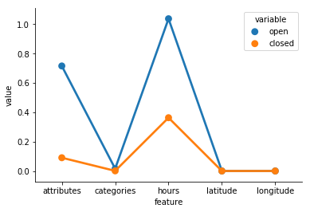

```python
nulls_count = pd.DataFrame({"open":(b[b.is_open == True].isnull().sum()/len(b[b.is_open == False])).round(5),
                           "closed":(b[b.is_open == False].isnull().sum()/len(b[b.is_open == False])).round(5)})

nulls_count = nulls_count[(nulls_count.open > 0) | (nulls_count.closed > 0)]
nulls_count["feature"] = nulls_count.index
nulls_count_melted = pd.melt(nulls_count, id_vars=['feature'], value_vars=['open', 'closed'])
sns.pointplot(x="feature", y="value", hue="variable", kind="point", data=nulls_count_melted)
sns.despine()
plt.show()
```

No, closed business have much lesser nulls

### Class imbalance: Business

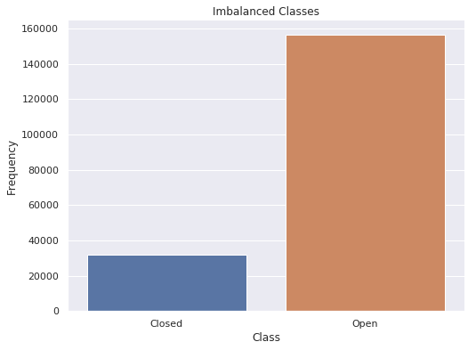

```python
sns.set(rc={'figure.figsize':(8,6)})
sns.countplot(b.is_open)
plt.title("Imbalanced Classes")
plt.xticks([0,1], ("Closed", "Open"))
plt.xlabel("Class")
plt.ylabel("Frequency")
sns.despine()
plt.show()
```

```python
pd.value_counts(b.is_open)/b.shape[0]
```

```
1    0.830391
0    0.169609
Name: is_open, dtype: float64
```

```python
b.drop("hours", axis=1, inplace=True)
b = b.drop(b[b.categories.isnull()].index)
b = b.drop(b[(b.latitude.isnull()) | (b.longitude.isnull()) ].index)
b = b.drop("attributes", axis=1)
# nulls in percent
((b.isnull().sum()/len(b)) * 100).round(5)
```

```
address         0.0
business_id     0.0
categories      0.0
city            0.0
is_open         0.0
latitude        0.0
longitude       0.0
name            0.0
neighborhood    0.0
postal_code     0.0
review_count    0.0
stars           0.0
state           0.0
dtype: float64
```

### Binarize Categories

A business is labeled to more than one categories. Converting them to binary will make filtering and analyzing very easy. Let me try to one-hot encode them.

```python
b.categories.head()
```

```
0    Tours, Breweries, Pizza, Restaurants, Food, Ho...
1    Chicken Wings, Burgers, Caterers, Street Vendo...
2    Breakfast & Brunch, Restaurants, French, Sandw...
3                        Insurance, Financial Services
4    Home & Garden, Nurseries & Gardening, Shopping...
Name: categories, dtype: object
```

Splitting by comma works except for businesses that have a single category seprated by commas.

- Books, Mags, Music & Video
- Used, Vintage & Consignment
- Beer, Wine & Spirits
- Wills, Trusts, & Probates

Since there is no syntatical difference beween single category containing comma and multiple categories separated by comma, i couln't find a regex expression to deal with this problem. Replacing manually is the remaining option.

```python
b.loc[:, 'categories'] = b.categories.str.replace("Books, Mags, Music & Video", "Books+Mags+ & MusicVideo")
b.loc[:, 'categories'] = b.categories.str.replace("Used, Vintage & Consignment", "Used+Vintage+ & Consignment")
b.loc[:, 'categories'] = b.categories.str.replace("Beer, Wine & Spirits", "Beer+Wine & Spirits")
b.loc[:, 'categories'] = b.categories.str.replace("Wills, Trusts, & Probates", "Wills+Trusts+&Probates")
```

One hot encoding is for single label categorical variables. For multiple labels Scikit-learn's MultiLabelBinarizer is the way to go.

```python
# split by comma
categories_series = b.categories.apply(lambda x: x.split(","))
# a  lambda function to convert the following data structure
# [list(['Tours', ' Breweries', ' Pizza', ' Restaurants', ' Food', ' Hotels & Travel'])
# to
# ['Tours', ' Breweries', ' Pizza', ' Restaurants', ' Food', ' Hotels & Travel']
take_out_list = lambda x: list(x)
# get 2D list
categories_2D_list = take_out_list(categories_series)
# remove leading and trailing white spaces
for alist in categories_2D_list:
    alist[:] = [category.strip() for category in alist]
#print(categories_2D_list[:3])
from sklearn.preprocessing import MultiLabelBinarizer
mlb = MultiLabelBinarizer()
categories_binarized = mlb.fit_transform(categories_2D_list)
#print(categories_binarized.shape)
#print(mlb.classes_.shape)
# mlb.classes_ returns the unique categories found by the binarizer
categories_binarized_df = pd.DataFrame(categories_binarized, columns=list(mlb.classes_))
categories_binarized_df.sample(10)
```

|  | 3D Printing | ATV Rentals/Tours | Acai Bowls | Accessories | Accountants | Acne Treatment | Active Life | Acupuncture | Addiction Medicine | Adoption Services | ... | Wine Tasting Room | Wine Tours | Wineries | Women's Clothing | Workers Compensation Law | Wraps | Yelp Events | Yoga | Ziplining | Zoos |
| --- | --- | --- | --- | --- | --- | --- | --- | --- | --- | --- | --- | --- | --- | --- | --- | --- | --- | --- | --- | --- | --- |
| 74237 | 0 | 0 | 0 | 0 | 0 | 0 | 0 | 0 | 0 | 0 | ... | 0 | 0 | 0 | 0 | 0 | 0 | 0 | 0 | 0 | 0 |
| 39197 | 0 | 0 | 0 | 0 | 0 | 0 | 1 | 0 | 0 | 0 | ... | 0 | 0 | 0 | 0 | 0 | 0 | 0 | 0 | 0 | 0 |
| 81969 | 0 | 0 | 0 | 0 | 0 | 0 | 0 | 0 | 0 | 0 | ... | 0 | 0 | 0 | 0 | 0 | 0 | 0 | 0 | 0 | 0 |
| 152614 | 0 | 0 | 0 | 0 | 0 | 0 | 0 | 0 | 0 | 0 | ... | 0 | 0 | 0 | 0 | 0 | 0 | 0 | 0 | 0 | 0 |
| 43584 | 0 | 0 | 0 | 0 | 0 | 0 | 0 | 0 | 0 | 0 | ... | 0 | 0 | 0 | 0 | 0 | 0 | 0 | 0 | 0 | 0 |
| 119931 | 0 | 0 | 0 | 0 | 0 | 0 | 0 | 0 | 0 | 0 | ... | 0 | 0 | 0 | 0 | 0 | 0 | 0 | 0 | 0 | 0 |
| 113925 | 0 | 0 | 0 | 0 | 0 | 0 | 0 | 0 | 0 | 0 | ... | 0 | 0 | 0 | 0 | 0 | 0 | 0 | 0 | 0 | 0 |
| 166359 | 0 | 0 | 0 | 0 | 0 | 0 | 0 | 0 | 0 | 0 | ... | 0 | 0 | 0 | 0 | 0 | 0 | 0 | 0 | 0 | 0 |
| 34309 | 0 | 0 | 0 | 0 | 0 | 0 | 0 | 0 | 0 | 0 | ... | 0 | 0 | 0 | 0 | 0 | 0 | 0 | 0 | 0 | 0 |
| 45538 | 0 | 0 | 0 | 0 | 0 | 0 | 0 | 0 | 0 | 0 | ... | 0 | 0 | 0 | 0 | 0 | 0 | 0 | 0 | 0 | 0 |

10 rows × 1299 columns

```python
mlb.classes_
```

```
array(['3D Printing', 'ATV Rentals/Tours', 'Acai Bowls', ..., 'Yoga',
       'Ziplining', 'Zoos'], dtype=object)
```

### Top 20 Business Categories

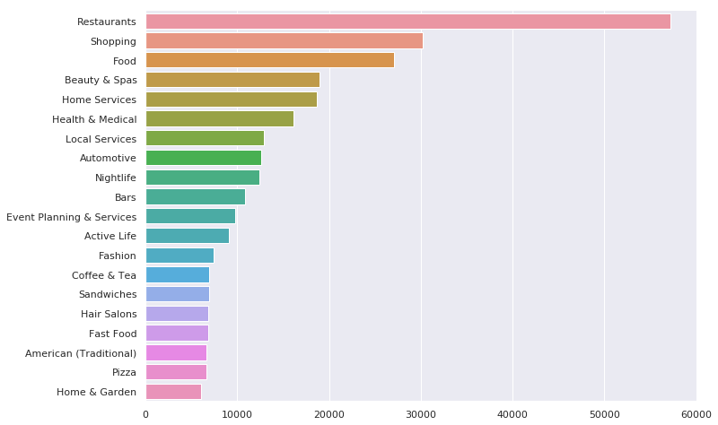

```python
top_20_categories = categories_binarized_df.sum().sort_values(ascending=False)[:20]
sns.set(rc={'figure.figsize':(11,8)})
ax = sns.barplot(y=top_20_categories.index, x=top_20_categories.values, orient='h')
sns.despine()
```

### Are these categories combined in groups of 3 or more?

```python
# find the number of total busineses
total_business = categories_binarized_df.shape[0]
combinations_of_top20 = categories_binarized_df[top_20_categories.index].apply(lambda x: list(x.index[np.where(x != 0)]), axis=1)
# convert index to string to make it hashable
import json
# dumps converts list to string
combinations_of_top20 = combinations_of_top20.map(json.dumps)
value_counts_top20 = combinations_of_top20.value_counts()
value_counts_top20
count_g_2 = 0
for c in value_counts_top20.index:
    # count combinations of two or more categories
    # loads converts back to list
    if(len(json.loads(c)) > 2):
        count_g_2 += value_counts_top20.loc[c]
print(count_g_2)
print(np.round((count_g_2/total_business) * 100, 2), "%")
```

```
26718
14.21 %
```

Only 14% of all businesses have combined categories from the top-20 categories. This indicates that most of these are top level categories encompassing many businesses.

```python
total_business
```

```
188045
```

### Which of these top business categories have higher closure?

```python
top_20_categories.index
```

```
Index(['Restaurants', 'Shopping', 'Food', 'Beauty & Spas', 'Home Services',
       'Health & Medical', 'Local Services', 'Automotive', 'Nightlife', 'Bars',
       'Event Planning & Services', 'Active Life', 'Fashion', 'Coffee & Tea',
       'Sandwiches', 'Hair Salons', 'Fast Food', 'American (Traditional)',
       'Pizza', 'Home & Garden'],
      dtype='object')
```

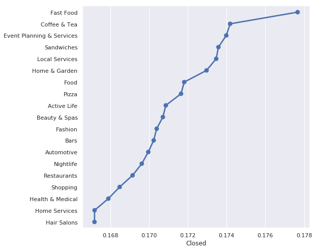

```python
# concatenate is_open info to the binaried categories data
open_close_df = pd.concat([categories_binarized_df[top_20_categories.index], b.is_open], axis=1)
# find all open businesses
open_df = open_close_df[open_close_df.is_open ==1]
# find all closed businesses
close_df = open_close_df[open_close_df.is_open ==0]
# sum across columns to find number of open business in each column(category)
open_close_count = (pd.concat([open_df.sum(), close_df.sum()], axis=1))
# change the default column names
open_close_count.columns = ["Open", "Closed"]
#print(open_close_count)
# divide the counts by the total businesses in each category
open_close_count_normalized = open_close_count.div(open_df.sum() + close_df.sum(), axis=0).sort_values(by="Closed", ascending=False)[:-2]
sns.set(rc={'figure.figsize':(8,8)})
ax = sns.pointplot(x=open_close_count_normalized.Closed, y=open_close_count_normalized.index, orient='h')
sns.despine()
```

### Number of Reviews: Restaurants vs Shopping

```python
categories_binarized_df["business_id"] = b.business_id.values
categories_binarized_df["is_open"] = b.is_open.values

restaurants_df =  categories_binarized_df[categories_binarized_df.Restaurants == 1]
shopping_df = categories_binarized_df[categories_binarized_df.Shopping == 1]

total_reviews = 5996996

# # the code below takes time. The results are saved to file and loaded in the next cell

# csize = 1e6
# review_reader = pd.read_json("yelp_academic_dataset_review.json", lines=True, chunksize=csize)


# num_restaurant_reviews = 0
# num_shopping_reviews = 0
# total_reviews = 0
# for i, r in enumerate(review_reader):
#     total_reviews += r.shape[0]
#     print("working on chunk ",i," shape =", r.shape[0])
#     # count number of restaurant reviews found in chunk r
#     num_restaurant_reviews += pd.merge(restaurants_df, r, on=["business_id"]).shape[0]
#     # count number of shopping reviews found in chunk r
#     num_shopping_reviews += pd.merge(shopping_df, r, on=["business_id"]).shape[0]


# pickle.dump(num_restaurant_reviews, open("yelp-dataset/num_restaurant_reviews.sav", 'wb'))
# pickle.dump(num_shopping_reviews,open("yelp-dataset/num_shopping_reviews.sav", 'wb'))
```

```python
num_restaurant_reviews = pickle.load(open("yelp-dataset/num_restaurant_reviews.sav", 'rb'))
num_shopping_reviews = pickle.load(open("yelp-dataset/num_shopping_reviews.sav", 'rb'))

print("Percent of Restaurant Businesses: {:.2f}".format(restaurants_df.shape[0] / total_business))
print("Percent of Shopping Businesses: {:.2f}".format(shopping_df.shape[0] / total_business))
print()
print("Percent of Restaurant Reviews: {:.2f}".format(num_restaurant_reviews / total_reviews))
print("Percent of Shopping Reviews: {:.2f}".format(num_shopping_reviews / total_reviews))
```

```
Percent of Restaurant Businesses: 0.30
Percent of Shopping Businesses: 0.16

Percent of Restaurant Reviews: 0.61
Percent of Shopping Reviews: 0.07
```

There are a lot of restaurants on Yelp. Second top are shopping businesses. When you see the number of reviews restaurants take more share than their number. Thus, restaurants are highly reviewed.

### Reviews by Year

```python
#The following code takes time. Saved data is loaded in the next cell

# csize=1e6
# review_reader = pd.read_json("yelp_academic_dataset_review.json", lines=True, chunksize=csize)
# total_reviews = 0
# restaurant_open_review_years = []
# restaurant_closed_review_years = []
# shopping_open_review_years = []
# shopping_closed_review_years = []

# for i, r in enumerate(review_reader):
#     total_reviews += r.shape[0]
#     print("working on chunk ",i," shape =", r.shape[0])

#     restaurant_reviewsR = pd.merge(restaurants_df, r, on=["business_id"])

#     restaurant_reviews_closed = restaurant_reviewsR[restaurant_reviewsR.is_open == 0]
#     restaurant_reviews_open = restaurant_reviewsR[restaurant_reviewsR.is_open == 1]


#     restaurant_closed_review_years.append(pd.to_datetime(restaurant_reviews_closed.date.dt.year).values)
#     restaurant_open_review_years.append(pd.to_datetime(restaurant_reviews_open.date.dt.year).values)

#     shopping_restaurantR= pd.merge(shopping_df, r, on=["business_id"])

#     shopping_reviews_closed = shopping_restaurantR[shopping_restaurantR.is_open == 0]
#     shopping_reviews_open = shopping_restaurantR[shopping_restaurantR.is_open == 1]

#     shopping_closed_review_years.append(pd.to_datetime(shopping_reviews_closed.date.dt.year).values)
#     shopping_open_review_years.append(pd.to_datetime(shopping_reviews_open.date.dt.year).values)

# # save the lists to file
# pickle.dump(restaurant_open_review_years, open("yelp-dataset/restaurant_open_review_years.sav", 'wb'))
# pickle.dump(restaurant_closed_review_years, open("yelp-dataset/restaurant_closed_review_years.sav", 'wb'))
# pickle.dump(shopping_open_review_years, open("yelp-dataset/shopping_open_review_years.sav",'wb'))
# pickle.dump(shopping_closed_review_years, open("yelp-dataset/shopping_closed_review_years.sav", 'wb'))
```

```python
# load lists from file
restaurant_open_review_years = pickle.load(open("yelp-dataset/restaurant_open_review_years.sav", 'rb'))
restaurant_closed_review_years = pickle.load(open("yelp-dataset/restaurant_closed_review_years.sav", 'rb'))
shopping_open_review_years = pickle.load(open("yelp-dataset/shopping_open_review_years.sav", 'rb'))
shopping_closed_review_years = pickle.load(open("yelp-dataset/shopping_closed_review_years.sav", 'rb'))

restaurant_open_review_years = np.concatenate(restaurant_open_review_years).ravel()
restaurant_closed_review_years = np.concatenate(restaurant_closed_review_years).ravel()
shopping_open_review_years = np.concatenate(shopping_open_review_years).ravel()
shopping_closed_review_years = np.concatenate(shopping_closed_review_years).ravel()
```

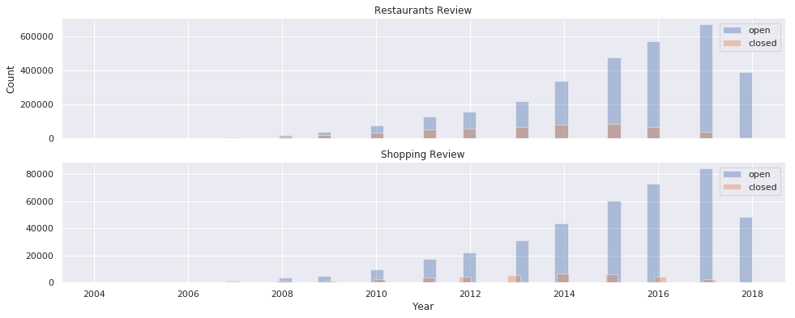

```python
fig, (ax1,ax2) = plt.subplots(2,1,figsize=(16,6), sharex= True, sharey=False)

sns.set(rc={'figure.figsize':(4,4)})
sns.distplot(restaurant_open_review_years.astype(int), kde=False, label="open", ax=ax1)
sns.distplot(restaurant_closed_review_years.astype(int), kde=False, label = "closed", ax=ax1)
ax1.legend()
ax1.set_ylabel("Count")
ax2.set_xlabel("Year")
ax1.set_title("Restaurants Review")

sns.distplot(shopping_open_review_years.astype(int), kde=False, label="open", ax=ax2)
sns.distplot(shopping_closed_review_years.astype(int), kde=False, label = "closed", ax=ax2)
ax2.set_title("Shopping Review")
ax2.set_xlabel("Year")
ax1.set_ylabel("Count")
sns.despine()
ax2.legend()
plt.show()
```

The information on when a restaurant is closed is not provided by Yelp. We can only approximate the rate of closure based on the distrubiton of reviews. The graph shows that restaurants started recieving reviews on Yelp since 2004 and the reviews continued to increase. The year 2017 is the peak year for open restaurants. Many restaurants that were reviewed in 2014/15 are closed. We can not be sure whether they were closed in the same year or later.

Many shopping businesses that were reviewed in 2014-15 are closed by now.

### Approxmating Restaurants Age

```python
#The following code takes 15 minutes. Saved data is loaded in the next cell

# csize = 1e5
# review_reader = pd.read_json("yelp_academic_dataset_review.json", lines=True, chunksize=csize)
# total_reviews = 0
# #restaurant_open_last_review_year = []
# #hopping_open_last_review_year =
# #hopping_closed_last_review_year = []
# for i, r in enumerate(review_reader):
#     with warnings.catch_warnings():
#         warnings.simplefilter("ignore")
#         print("working on chunk ",i," shape =", r.shape[0])

#         restaurant_reviewsR = pd.merge(restaurants_df, r, on=["business_id"])

#         restaurant_reviewsR["review_year"] = pd.to_datetime(restaurant_reviewsR.date.dt.year)

#         if(i == 0):
#             restaurants_open_year = restaurant_reviewsR[["business_id", "review_year"]].groupby("business_id")["review_year"].min()
#             restaurants_closed_year = restaurant_reviewsR[["business_id", "review_year"]].groupby("business_id")["review_year"].max()

#         else:
#             restaurants_open_year = pd.concat([restaurants_open_year, restaurant_reviewsR[["business_id", "review_year"]].groupby("business_id")["review_year"].min()])
#             restaurants_closed_year = pd.concat([restaurants_closed_year, restaurant_reviewsR[["business_id", "review_year"]].groupby("business_id")["review_year"].max()])

# # save the dataframes to file
# pickle.dump(restaurants_open_year, open("yelp-dataset/restaurants_open_year.sav", 'wb'))
# pickle.dump(restaurants_closed_year, open("yelp-dataset/restaurants_closed_year.sav", 'wb'))
```

```python
# open and close in the file names refer to earliest review year and most recent review years
# it is a naming mistake made when dumping the objects
earliest_review_year_all = pickle.load(open("yelp-dataset/restaurants_open_year.sav", 'rb'))
most_recent_review_year_all = pickle.load(open("yelp-dataset/restaurants_closed_year.sav", 'rb'))

earliest_review_year = earliest_review_year_all.groupby("business_id").min()
most_recent_review_year = most_recent_review_year_all.groupby("business_id").max()

restaurants_dates = pd.concat([earliest_review_year, most_recent_review_year], axis=1)
restaurants_dates.columns = ["earliest_review_year", "most_recent_review_year"]
# filter required attributes
restaurants_only = pd.merge(b[["business_id", "latitude", "longitude", "stars","review_count", "is_open"]],
                            restaurants_dates, on="business_id")
restaurants_only.head()
```

|  | business_id | latitude | longitude | stars | review_count | is_open | earliest_review_year | most_recent_review_year |
| --- | --- | --- | --- | --- | --- | --- | --- | --- |
| 0 | Apn5Q_b6Nz61Tq4XzPdf9A | 51.091813 | -114.031675 | 4.0 | 24 | 1 | 1970-01-01 00:00:00.000002013 | 1970-01-01 00:00:00.000002018 |
| 1 | AjEbIBw6ZFfln7ePHha9PA | 35.960734 | -114.939821 | 4.5 | 3 | 0 | 1970-01-01 00:00:00.000002017 | 1970-01-01 00:00:00.000002017 |
| 2 | O8S5hYJ1SMc8fA4QBtVujA | 45.540503 | -73.599300 | 4.0 | 5 | 0 | 1970-01-01 00:00:00.000002014 | 1970-01-01 00:00:00.000002016 |
| 3 | 6OuOZAok8ikONMS_T3EzXg | 43.712946 | -79.632763 | 2.0 | 7 | 1 | 1970-01-01 00:00:00.000002012 | 1970-01-01 00:00:00.000002014 |
| 4 | 8-NRKkPY1UiFXW20WXKiXg | 33.448106 | -112.341302 | 2.5 | 40 | 1 | 1970-01-01 00:00:00.000002008 | 1970-01-01 00:00:00.000002018 |

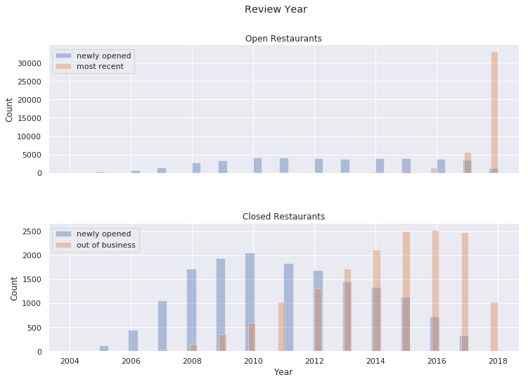

```python
fig, (ax1,ax2) = plt.subplots(2,1,figsize=(12,8), sharex=True)
fig.subplots_adjust(hspace = 0.4, wspace = 0.4)

sns.set(rc={'figure.figsize':(4,4)})

open_earliest_years = restaurants_only[restaurants_only.is_open == True].earliest_review_year.values.astype(int)
open_most_recent_years = restaurants_only[restaurants_only.is_open == True].most_recent_review_year.values.astype(int)
closed_earliest_years = restaurants_only[restaurants_only.is_open == False].earliest_review_year.values.astype(int)
closed_most_recent_years = restaurants_only[restaurants_only.is_open == False].most_recent_review_year.values.astype(int)


sns.distplot(open_earliest_years, kde=False, label="newly opened", ax=ax1)
sns.distplot(open_most_recent_years, kde=False, label = "most recent", ax=ax1)

sns.distplot(closed_earliest_years, kde=False, label="newly opened", ax=ax2)
sns.distplot(closed_most_recent_years, kde=False, label = "out of business", ax=ax2)

ax1.set_title("Open Restaurants")
ax2.set_title("Closed Restaurants")

ax1.legend(loc="upper left")
ax2.legend(loc="upper left")
ax1.set_ylabel("Count")
ax2.set_ylabel("Count")

ax2.set_xlabel("Year")
plt.suptitle("Review Year")
sns.despine()
```

We are approximating the earliest year as the opening year of a restaurant. For currently closed restaurants, the most recent year is approximated as the out of business year.

Looking at the upper graph; almost all currently open restaurants were reviewed within the last 2 years. The distriubtion of earliest review year is left skewed. Since 2010 similar number of restaurants were opened

They are many contributing factors that are outside the scope of this analysis.

```python
len(set(restaurants_only.business_id))
```

```
57173
```

There are 57173 restaurants on Yelp

### Create Age Feature

```python
# subtract earliest review year from 2018
restaurants_only["age"] = 2018 - restaurants_only.earliest_review_year.values.astype(int)
# select features
restaurants_only = restaurants_only[['business_id', 'latitude', 'longitude', 'stars', 'review_count','age', 'is_open']]
restaurants_only.age.describe()
```

```
count    57173.000000
mean         5.993266
std          3.145764
min          0.000000
25%          3.000000
50%          6.000000
75%          8.000000
max         14.000000
Name: age, dtype: float64
```

The maximum age is only 14 years because Yelp started in 2004

### Class Imbalance: Restaurants

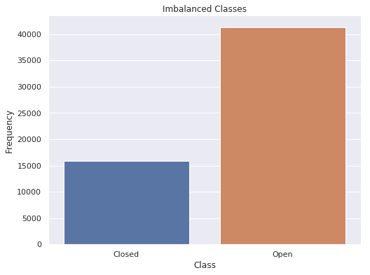

```python
sns.set(rc={'figure.figsize':(8,6)})
sns.countplot(restaurants_only.is_open)
plt.title("Imbalanced Classes")
plt.xticks([0,1], ("Closed", "Open"))
plt.xlabel("Class")
plt.ylabel("Frequency")
sns.despine()
plt.show()
```

```python
pd.value_counts(restaurants_only.is_open)/restaurants_only.shape[0]
```

```
1    0.723104
0    0.276896
Name: is_open, dtype: float64
```

Open and Closed Restaurants are not as imbalanced as they are for all busineses. Out of all businesses 83% of them are open but among all restaurants 72% of them are open.

```python
restaurants_only.head()
```

|  | business_id | latitude | longitude | stars | review_count | age | is_open |
| --- | --- | --- | --- | --- | --- | --- | --- |
| 0 | Apn5Q_b6Nz61Tq4XzPdf9A | 51.091813 | -114.031675 | 4.0 | 24 | 5 | 1 |
| 1 | AjEbIBw6ZFfln7ePHha9PA | 35.960734 | -114.939821 | 4.5 | 3 | 1 | 0 |
| 2 | O8S5hYJ1SMc8fA4QBtVujA | 45.540503 | -73.599300 | 4.0 | 5 | 4 | 0 |
| 3 | 6OuOZAok8ikONMS_T3EzXg | 43.712946 | -79.632763 | 2.0 | 7 | 6 | 1 |
| 4 | 8-NRKkPY1UiFXW20WXKiXg | 33.448106 | -112.341302 | 2.5 | 40 | 10 | 1 |

### Outliers

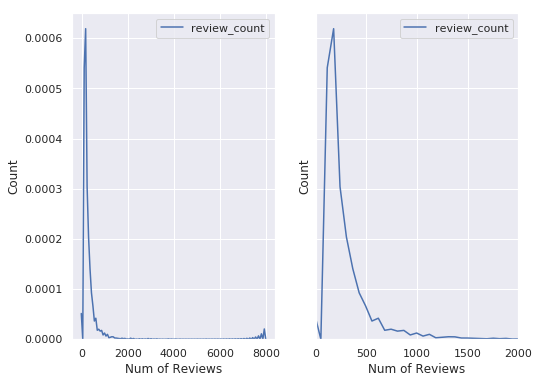

```python
fig, (ax1,ax2) = plt.subplots(1,2,figsize=(8,6), sharey=True)
# making spaces between subplots
#fig.subplots_adjust(hspace = 0.2, wspace = 0.2)
ax1.set_xlabel("Num of Reviews")
ax2.set_xlabel("Num of Reviews")
ax1.set_ylabel("Count")
ax2.set_ylabel("Count")
sns.kdeplot(restaurants_only.review_count.sort_values(), ax=ax1)
sns.kdeplot(restaurants_only.review_count.sort_values(), ax=ax2)
ax2.set_xlim(0, 2000)
plt.show()
```

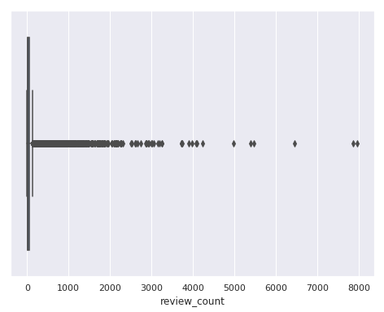

```python
sns.boxplot(restaurants_only.review_count.sort_values())
plt.show()
```

```python
from scipy import stats
z = np.abs(stats.zscore(restaurants_only.review_count))
threshold = 3
outlier_businesses = list(np.where(z > 3)[0])
print("Number of restaurants: ", restaurants_only.shape[0])
print("Number of outliers: ", len(outlier_businesses))
```

```
Number of restaurants:  57173
Number of outliers:  786
```

Removing 786 businesses will not harm because there is plenty of data.

```python
business_ids = restaurants_only.iloc[outlier_businesses, 0].to_frame()
pd.merge(business_ids, b, on=["business_id"])[["name", "state", "review_count", "address"]].sample(10)
```

|  | name | state | review_count | address |
| --- | --- | --- | --- | --- |
| 571 | Republic Ramen + Noodles | AZ | 623 | 1301 E University Dr |
| 152 | Bitter & Twisted Cocktail Parlour | AZ | 834 | 1 W Jefferson St |
| 434 | Cafe Monarch | AZ | 650 | 6939 E 1st Ave |
| 558 | Nacho Daddy Henderson | NV | 598 | 9925 S Eastern Ave |
| 531 | Pin-Up Pizza | NV | 552 | 3667 Las Vegas Blvd S |
| 577 | Hugo's Cellar | NV | 844 | 202 Fremont St |
| 516 | Durant's | AZ | 824 | 2611 N Central Ave |
| 574 | The Goodwich | NV | 610 | 900 S Las Vegas Blvd, Ste 120 |
| 580 | Nacho Daddy | NV | 1635 | 3663 Las Vegas Blvd, Ste 595 |
| 26 | STK Las Vegas | NV | 1464 | 3708 Las Vegas Blvd S |

These must be very popular places because they are highly reviewed. They may create problems during text processing because a lot of words will be used in their reviews.

```python
# check shape of dataframe before removal
restaurants_only.shape
```

```
(57173, 7)
```

```python
# remove outlier businesses
restaurants_only = restaurants_only.drop(outlier_businesses)
```

```python
# check shape again
restaurants_only.shape
```

```
(56387, 7)
```

```python
# !python -m spacy download en
# import nltk
# nltk.download('punkt')
# nltk.download('averaged_perceptron_tagger')
# nltk.download('wordnet')
```

## Working on Yelp Reviews Data

```python
import spacy
nlp = spacy.load("en", disable=['parser', 'ner'])
doc = nlp("She was dancing and walking in the garden. Flowers and plants are refreshing. I have a flower factory")
for token in doc:
    print(token.lemma_)
```

```
-PRON-
be
dance
and
walk
in
the
garden
.
flower
and
plant
be
refresh
.
-PRON-
have
a
flower
factory
```

```python
# using spacy lemmatizer as a class
#from spacy.lemmatizer import Lemmatizer
#from spacy.lang.en import LEMMA_INDEX, LEMMA_EXC, LEMMA_RULES
#lemmatizer = Lemmatizer(LEMMA_INDEX, LEMMA_EXC, LEMMA_RULES)
#print(nltk.pos_tag(["traumatizing"]))
#print(lemmatizer("hers", "P"))

# nltk classes used for tokenization and lemmatization
#from nltk import word_tokenize
#from nltk.stem import WordNetLemmatizer
```

### Custom Tokenizer-Lemmatizer

Scikit-learn's vectorizers don't convert words into their base form by default. The custom lemmatizer/tokenizer is passed as tokenizer for CountVectorizer and TfIdfVectorizer Objects.

I tried to use NLTK's word_tokenize and WordNetLemmatizer. NLTK methods work on a specified part of speech, the default is noun. It is not flexible to work for multiple part of speech.

Spacy is very flexible. When a spacy object is created, it will automatically know the part of speech of all tokens in the given document. It converts words into their base form depending on their POS tag. The only problem with spacy is its speed. Creating a spacy document involves tagging, parsing and named entity recognition. I disabled the steps that I don't need which increased its speed.

```python
import spacy
nlp = spacy.load("en", disable=['parser', 'ner'])
# Use custom tokenizer and lemmatizer
def lemmatizer_tokenize(a_review):
    # remove extra space and new line
    a_review = ' '.join(a_review.split())
    a_review = nlp(a_review)
    words = [token.lemma_ for token in a_review
                if (
                    not token.is_digit and
                    not token.is_punct and
                    not token.is_stop and
                    token.lemma_ != "-PRON-"
                )
            ]
    return words
```

```python
from spacy import displacy
displacy.render(doc, style='dep', jupyter=True, options={'distance': 90})
```

[figure not shown]

```python
# testing lemmatizer
lemmatizer_tokenize("Dancing entertains people. The girl was dancing when the shooters entered the club")
```

```
['dancing',
 'entertain',
 'people',
 'the',
 'girl',
 'dance',
 'shooter',
 'enter',
 'club']
```

The first "Dancing" is a noun. The second "dancing" is a verb. Spacy only converted the verb to its base form. Shooters is a noun, converted to shooter. "Entered" is a verb, converted to enter.

```python
restaurants_only.head()
```

|  | business_id | latitude | longitude | stars | review_count | age | is_open |
| --- | --- | --- | --- | --- | --- | --- | --- |
| 0 | Apn5Q_b6Nz61Tq4XzPdf9A | 51.091813 | -114.031675 | 4.0 | 24 | 5 | 1 |
| 1 | AjEbIBw6ZFfln7ePHha9PA | 35.960734 | -114.939821 | 4.5 | 3 | 1 | 0 |
| 2 | O8S5hYJ1SMc8fA4QBtVujA | 45.540503 | -73.599300 | 4.0 | 5 | 4 | 0 |
| 3 | 6OuOZAok8ikONMS_T3EzXg | 43.712946 | -79.632763 | 2.0 | 7 | 6 | 1 |
| 4 | 8-NRKkPY1UiFXW20WXKiXg | 33.448106 | -112.341302 | 2.5 | 40 | 10 | 1 |

```python
# #tokenizer pattern and replace practice
# myvect1 = CountVectorizer(stop_words = 'english')
# myvect2 = CountVectorizer(stop_words = 'english')

# somelist = pd.Series(["Tinse is great ጥሩ ˈdäNG person", "Ethiopia is my country!", "15Brown fox", "Quick", "13 it is nice"])
# somelist2 = pd.Series(["Tinse is great ጥሩ",  "däNG person", "fox"])

# somelist = somelist.str.replace(r'(?u)[^\w\s]+|[\d]+', '')
# somelist2 = somelist2.str.replace(r'(?u)[^\w\s]+|[\d]+', '')
# #print(somelist)
# transformed1 = myvect1.fit(somelist)
# transformed2 = myvect2.fit(somelist2)

# #print(myvect.vocabulary_)
# myvect1.get_feature_names()
# myvect2.get_feature_names()
# the_vocabulary = set(sorted(myvect1.get_feature_names() + myvect2.get_feature_names()))
# myvectx = TfidfVectorizer(vocabulary=the_vocabulary)
# myvectx.vocabulary
# sparse.csr_matrix([1,2,3,0])
```

### Space-wise Random Clustering

### 1. Simple TF-IDF Features

Inverse document frequency is calculated on the whole dataset. Doing train/test split after tfidf vectorization leaks data from the train set to the test set. I vectorized train and test sets separately using the same vocabulary.

#### Train/Test Split

```python
X = restaurants_only.drop("is_open", axis=1)
# # change is_open to is_closed
y = np.where(restaurants_only["is_open"] == 0 , 1, 0)
# stratified sampling
X_train, X_test, y_train, y_test = train_test_split(X, y, test_size=0.2, random_state=20, shuffle=True, stratify=y)
X_train = X_train.reset_index(drop=True)
X_test = X_test.reset_index(drop=True)
# combine x and y to ease feature engineering
# shallow copy
train = X_train.copy(deep=True)
train["is_closed"] = y_train
test = X_test.copy(deep=True)
# shallow copy
test["is_closed"] = y_test
print(train.shape)
train.head()
```

```
(45109, 7)
```

|  | business_id | latitude | longitude | stars | review_count | age | is_closed |
| --- | --- | --- | --- | --- | --- | --- | --- |
| 0 | rGJt5LSMUuaMufNuXcyb_A | 43.678838 | -79.720137 | 3.0 | 17 | 9 | 0 |
| 1 | G5gkRgTMqN0iIpyoW6oTYg | 43.657790 | -79.487801 | 3.5 | 9 | 3 | 1 |
| 2 | Qg4Ou9YwqXf10zxQGrw0sA | 43.774523 | -79.177464 | 3.5 | 11 | 6 | 1 |
| 3 | soqpbgQt0v4BrEOwV03FkQ | 33.334549 | -111.804860 | 3.5 | 22 | 7 | 1 |
| 4 | UPoM5nmUiklwqBV5pLuK7Q | 33.421371 | -111.893141 | 3.5 | 6 | 11 | 0 |

### Train-set

```python
# #Takes a lot of time. Saved models are loaded in the next cells
# import time
# from sklearn.feature_extraction.text import TfidfVectorizer
# csize=1e6
# start_time = time.time()
# review_reader = pd.read_json("yelp_academic_dataset_review.json", lines=True, chunksize=csize)
# from scipy import sparse
# for i, r in enumerate(review_reader):
#     # work on chunk2 only to save time
#     if(i < 2):
#         continue
#     if(i > 2):
#         break
#     print("working on chunk ",i," shape =", r.shape[0])
#     tfidf_train_reviews = pd.merge(train, r, on=["business_id"])
#     # save dense matrix to file
#     tfidf_train_reviews.to_csv("yelp-dataset/tfidf_train_reviews"+ str(i) + ".csv")
#     # tokens containing numbers, digits and underscore are ignored
#     tfidf_vectorizer_train = TfidfVectorizer(stop_words='english', min_df=0.001, tokenizer=lemmatizer_tokenize)
#     # remove punctuation and numbers
#     tfidf_train_reviews.text = tfidf_train_reviews.text.str.replace(r'[^\w\s]+|[\d]+', '')
#     tfidf_features_train = tfidf_vectorizer_train.fit_transform(tfidf_train_reviews.text)
#     # save vectorizer
#     pickle.dump(tfidf_vectorizer_train, open("yelp-dataset/tfidf_vectorizer_train"+ str(i) +".sav", 'wb'))

#     # save sparse matrix to file
#     sparse.save_npz("yelp-dataset/tfidf_features_train"+ str(i) + ".npz", tfidf_features_train)

#     print("shape of dense matrix: ", tfidf_train_reviews.shape)
#     print("shape of sparse matrix:(tfidf) ", tfidf_train_reviews.shape)
# print(time.time() - start_time)
```

#### Load the Vectors

```python
i = 2
tfidf_features_train = sparse.load_npz("yelp-dataset/tfidf_features_train" + str(i) + ".npz")
tfidf_vectorizer_train = pickle.load(open("yelp-dataset/tfidf_vectorizer_train"+ str(i) + ".sav", 'rb'))
tfidf_train_reviews = pd.read_csv("yelp-dataset/tfidf_train_reviews" + str(i) + ".csv", index_col=0)
# get the indices of reviews for each business id
reviews_indices_dict_tfidf_train = tfidf_train_reviews.business_id.groupby(tfidf_train_reviews.business_id).groups
```

#### Average Words Per Business

```python
import time
start_time = time.time()
num_of_sparse_features = len(tfidf_vectorizer_train.vocabulary_)
# k goes over the business ids
# i counts
the_sparse_matrices_tf_idf_train = []

for i, k in enumerate(reviews_indices_dict_tfidf_train.keys()):
    if( i % 10000 == 0):
        print("creating row: ", i)
    # convert to list: row indices for the reviews of k
    indices_for_sparse_matrix = list(reviews_indices_dict_tfidf_train[k])
    # find means column-wise
    means_sparse = tfidf_features_train[indices_for_sparse_matrix, :].mean(axis=0).tolist()[0]
    the_sparse_matrices_tf_idf_train.append(means_sparse)
pickle.dump(the_sparse_matrices_tf_idf_train, open("yelp-dataset/the_sparse_matrices_tf_idf_train.sav", "wb"))
print(time.time() - start_time)
```

```
creating row:  0
creating row:  10000
creating row:  20000
creating row:  30000
38.678393840789795
```

#### Prepare X and Y

```python
tf_idf_aggregate_train = sparse.csr_matrix(the_sparse_matrices_tf_idf_train)
# selected features
tfidf_train_reviews = tfidf_train_reviews[['business_id', 'stars_x', 'review_count', 'latitude','longitude','age', 'is_closed']]
# remove duplicates
tfidf_train_reviews.drop_duplicates(inplace=True)
# sort by business id
tfidf_train_reviews = tfidf_train_reviews.sort_values(by = "business_id").reset_index(drop=True)
# remove business id and move is_closed to the front
tfidf_train_reviews = tfidf_train_reviews[['is_closed', 'stars_x', 'review_count', 'latitude','longitude','age']]
# merge sparse and dense features
tf_idf_train_final = hstack((tfidf_train_reviews , tf_idf_aggregate_train)).tocsr()
tf_idf_train_final
```

```
<37998x3224 sparse matrix of type '<class 'numpy.float64'>'
	with 7496217 stored elements in Compressed Sparse Row format>
```

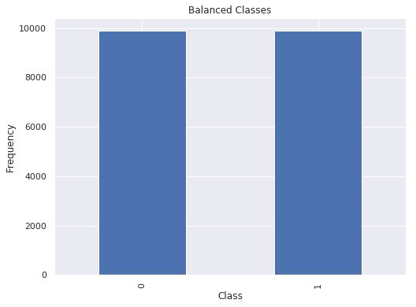

```
0    9903
1    9903
dtype: int64
```

```python
X_train = tf_idf_aggregate_train[:,1:]
y_train = tfidf_train_reviews.is_closed

from imblearn.under_sampling import RandomUnderSampler
rus = RandomUnderSampler(random_state=0)
X_train_tf_idf, y_train_tf_idf = rus.fit_sample(X_train, y_train)
count_classes = pd.value_counts(y_train_tf_idf.flatten(), sort=True).sort_index()
count_classes.plot(kind = 'bar')
plt.title("Balanced Classes")
plt.xlabel("Class")
plt.ylabel("Frequency")
plt.show()
print(count_classes)
```

### Test-set

```python
# #Takes a lot of time. Saved models are loaded in the next cells
# import time
# from sklearn.feature_extraction.text import TfidfVectorizer
# csize=1e6
# start_time = time.time()
# review_reader = pd.read_json("yelp_academic_dataset_review.json", lines=True, chunksize=csize)
# from scipy import sparse
# for i, r in enumerate(review_reader):
#     # work on chunk2 only to save time
#     if(i < 2):
#         continue
#     if(i > 2):
#         break
#     print("working on chunk ",i," shape =", r.shape[0])
#     tfidf_test_reviews = pd.merge(test, r, on=["business_id"])
#     # save dense matrix to file
#     tfidf_test_reviews.to_csv("yelp-dataset/tfidf_test_reviews"+ str(i) + ".csv")
#     # tokens containing numbers, digits and underscore are ignored
#     # remove punctuation and numbers
#     tfidf_test_reviews.text = tfidf_test_reviews.text.str.replace(r'[^\w\s]+|[\d]+', '')
#     # use train vectorizer
#     tfidf_features_test = tfidf_vectorizer_train.transform(tfidf_test_reviews.text)

#     # save sparse matrix to file
#     sparse.save_npz("yelp-dataset/tfidf_features_test"+ str(i) + ".npz", tfidf_features_test)

#     print("shape of dense matrix: ", tfidf_features_test.shape)
#     print("shape of sparse matrix:(tfidf) ", tfidf_test_reviews.shape)
# print(time.time() - start_time)
```

#### Load the Vectors

```python
i = 2
tfidf_features_test = sparse.load_npz("yelp-dataset/tfidf_features_test" + str(i) + ".npz")
tfidf_test_reviews = pd.read_csv("yelp-dataset/tfidf_test_reviews" + str(i) + ".csv", index_col=0)
# get the indices of reviews for each business id
reviews_indices_dict_tfidf_test = tfidf_test_reviews.business_id.groupby(tfidf_test_reviews.business_id).groups
```

#### Average words per Business

```python
import time
start_time = time.time()
num_of_sparse_features = len(tfidf_vectorizer_train.vocabulary_)
# k goes over the business ids
# i counts
the_sparse_matrices_tf_idf_test = []

for i, k in enumerate(reviews_indices_dict_tfidf_test.keys()):
    if( i % 10000 == 0):
        print("creating row: ", i)
    # convert to list: row indices for the reviews of k
    indices_for_sparse_matrix = list(reviews_indices_dict_tfidf_test[k])
    # find means column-wise
    means_sparse = tfidf_features_test[indices_for_sparse_matrix, :].mean(axis=0).tolist()[0]
    the_sparse_matrices_tf_idf_test.append(means_sparse)
pickle.dump(the_sparse_matrices_tf_idf_test, open("yelp-dataset/the_sparse_matrices_tf_idf_test.sav", "wb"))
print(time.time() - start_time)
```

```
creating row:  0
9.318789958953857
```

#### Prepare X and y

```python
tf_idf_aggregate_test = sparse.csr_matrix(the_sparse_matrices_tf_idf_test)
# selected features
tfidf_test_reviews = tfidf_test_reviews[['business_id', 'stars_x', 'review_count', 'latitude','longitude','age', 'is_closed']]
# remove duplicates
tfidf_test_reviews.drop_duplicates(inplace=True)
# sort by business id
tfidf_test_reviews = tfidf_test_reviews.sort_values(by = "business_id").reset_index(drop=True)
# remove business id and move is_closed to the front
tfidf_test_reviews = tfidf_test_reviews[['is_closed', 'stars_x', 'review_count', 'latitude','longitude','age']]
# merge sparse and dense features
tf_idf_test_final = hstack((tfidf_test_reviews , tf_idf_aggregate_test)).tocsr()
tf_idf_test_final
```

```
<9492x3224 sparse matrix of type '<class 'numpy.float64'>'
	with 1879499 stored elements in Compressed Sparse Row format>
```

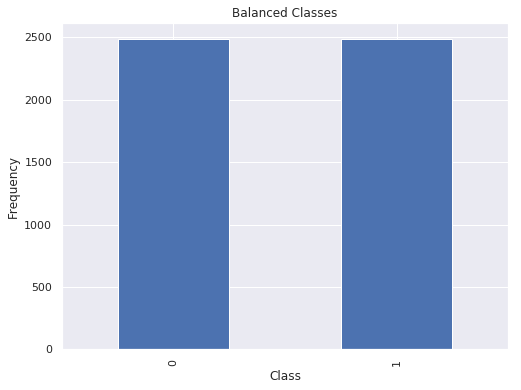

```
0    2490
1    2490
dtype: int64
```

```python
X_test = tf_idf_aggregate_test[:,1:]
y_test =  tfidf_test_reviews.is_closed

from imblearn.under_sampling import RandomUnderSampler
rus = RandomUnderSampler(random_state=0)
X_test_tf_idf, y_test_tf_idf = rus.fit_sample(X_test, y_test)
count_classes = pd.value_counts(y_test_tf_idf.flatten(), sort=True).sort_index()
count_classes.plot(kind = 'bar')
plt.title("Balanced Classes")
plt.xlabel("Class")
plt.ylabel("Frequency")
plt.show()
print(count_classes)
```

### 2. Bag of Words

```python
# Takes a lot of time(1hour). Saved models are loaded in the next cells
# import time
# from sklearn.feature_extraction.text import TfidfVectorizer, CountVectorizer
# csize=1e6
# start_time = time.time()
# review_reader = pd.read_json("yelp_academic_dataset_review.json", lines=True, chunksize=csize)
# from scipy import sparse
# for i, r in enumerate(review_reader):
#     # work on chunk2 only to save time
#     if(i < 2):
#         continue
#     if(i > 2):
#         break
#     print("working on chunk ",i," shape =", r.shape[0])
#     restaurants_reviews = pd.merge(restaurants_only, r, on=["business_id"])
#     # save dense matrix to file
#     restaurants_reviews.to_csv("yelp-dataset/restaurants_reviews"+ str(i) + ".csv")
#     # tokens containing numbers, digits and underscore are ignored

#     restaurants_vectorizer_bow2 = CountVectorizer(stop_words='english', min_df=0.001, tokenizer=lemmatizer_tokenize)

#     # remove punctuation and numbers
#     restaurants_reviews.text = restaurants_reviews.text.str.replace(r'[^\w\s]+|[\d]+', '')

#     bow_features2 = restaurants_vectorizer_bow2.fit_transform(restaurants_reviews.text)

#     # save vectorizer, the vectorizer contains the vocabulary
#     pickle.dump(restaurants_vectorizer_bow2, open("yelp-dataset/restaurants_vectorizer_bow"+ str(i) +".sav", 'wb'))
#     # save sparse matrix to file
#     sparse.save_npz("yelp-dataset/bow_features"+ str(i) + ".npz", bow_features2)

#     print("shape of dense matrix: ", restaurants_reviews.shape)
#     print("shape of sparse matrix:(tfidf) ", bow_features2.shape)
# print(time.time() - start_time)
```

#### Load the Vectors

```python
i = 2
bow_features2 = sparse.load_npz("yelp-dataset/bow_features" + str(i) + ".npz")
restaurants_vectorizer_bow2 = pickle.load(open("yelp-dataset/restaurants_vectorizer_bow"+ str(i) + ".sav", 'rb'))
restaurants_reviews = pd.read_csv("yelp-dataset/restaurants_reviews" + str(i) + ".csv", index_col=0)


# get the indices of reviews for each business id
reviews_indices_dict_bow = restaurants_reviews.business_id.groupby(restaurants_reviews.business_id).groups

print(bow_features2.shape)
print(restaurants_reviews.shape)
```

```
(476253, 3213)
(476253, 15)
```

#### Average Bag of Words Vectors Per Business

```python
import time
#takes 10 minutes
start_time = time.time()
num_of_sparse_features = len(restaurants_vectorizer_bow2.vocabulary_)
# k goes over the business ids
# i counts
the_sparse_matrices_bag = []

# closed restaurants
for i, k in enumerate(reviews_indices_dict_bow.keys()):
    if( i % 10000 == 0):
        print("creating row: ", i)
    # convert to list: row indices for the reviews of k
    indices_for_sparse_matrix = list(reviews_indices_dict_bow[k])
    # find means column-wise
    means_sparse = bow_features2[indices_for_sparse_matrix, :].mean(axis=0).tolist()[0]
    the_sparse_matrices_bag.append(means_sparse)
# save aggregate sparse matrix
pickle.dump(the_sparse_matrices_bag, open("yelp-dataset/the_sparse_matrices_bag.sav", "wb"))
print(time.time() - start_time)
```

```
creating row:  0
creating row:  10000
creating row:  20000
creating row:  30000
creating row:  40000
52.79873752593994
```

#### Prepare X and Y

```python
restaurants_bow_aggregate = sparse.csr_matrix(the_sparse_matrices_bag)
```

```python
# selected features
restaurants_reviews = restaurants_reviews[['business_id', 'stars_x', 'review_count', 'latitude','longitude','age', 'is_open']]
# remove duplicates
restaurants_reviews.drop_duplicates(inplace=True)
# sort by business id
restaurants_reviews = restaurants_reviews.sort_values(by = "business_id").reset_index(drop=True)
```

```python
# change is_open to is_closed
restaurants_reviews["is_closed"] = np.where(restaurants_reviews.is_open == 0 , 1, 0)
restaurants_reviews = restaurants_reviews[['is_closed', 'stars_x', 'review_count', 'latitude','longitude','age']]
# merge sparse and dense features
restaurants_bow_final = hstack((restaurants_reviews , restaurants_bow_aggregate)).tocsr()
restaurants_bow_final
```

```
<47490x3219 sparse matrix of type '<class 'numpy.float64'>'
	with 9374200 stored elements in Compressed Sparse Row format>
```

```python
restaurants_reviews.columns
```

```
Index(['is_closed', 'stars_x', 'review_count', 'latitude', 'longitude', 'age'], dtype='object')
```

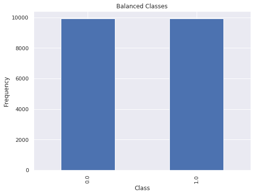

```
0.0    9914
1.0    9914
dtype: int64
```

```python
# include the target attribute in X. It will be used for IDF penalty
X = restaurants_bow_final
y = restaurants_bow_final[:,0].toarray()

# stratified sampling
X_train, X_test, y_train, y_test = train_test_split(X, y, test_size=0.2, random_state=20, shuffle=True, stratify=y)

from imblearn.under_sampling import RandomUnderSampler

rus = RandomUnderSampler(random_state=0)
X_train_bow, y_train_bow = rus.fit_sample(X_train, y_train)
X_test_bow, y_test_bow = rus.fit_sample(X_test, y_test)

count_classes = pd.value_counts(y_train_bow.flatten(), sort=True).sort_index()
count_classes.plot(kind = 'bar')
plt.title("Balanced Classes")
plt.xlabel("Class")
plt.ylabel("Frequency")
plt.show()
print(count_classes)
```

### 3. Bag of Words Penalized by IDF

```python
from sklearn.base import BaseEstimator, TransformerMixin

class IDFPenalty(BaseEstimator, TransformerMixin):
    def transform(self, X, *_):
        self.X = X
        # indices of open restaurants
        open_rest_indices = np.where(X[:, 0].toarray() == 0)[0]
        # indices of closed restauratns
        closed_rest_indices = np.where(X[:, 0].toarray() == 1)[0]
        num_of_open_restaurants = len(open_rest_indices)
        num_of_closed_restaurants = len(closed_rest_indices)

        # textual features start from index 6
        idf_open = np.log10(num_of_open_restaurants / (1 + np.array(self.X[open_rest_indices, 6:].sum(axis=0).tolist()[0]))).reshape(1,-1)
        idf_closed = np.log10(num_of_closed_restaurants / (1 + np.array(self.X[closed_rest_indices, 6:].sum(axis=0).tolist()[0]))).reshape(1,-1)

        self.X[open_rest_indices, 6:] = sparse.csr_matrix(self.X[open_rest_indices, 6:].toarray() * idf_closed)
        self.X[closed_rest_indices, 6:] = sparse.csr_matrix(self.X[closed_rest_indices, 6:].toarray() * idf_open)
        # remove is_closed column and return
        return self.X[:, 1:]

    def fit(self, *_):
        return self
```

```python
from sklearn.preprocessing import Normalizer
from sklearn.pipeline import Pipeline

pipeline = Pipeline([('IDF', IDFPenalty()),
                     ("scale", Normalizer())])
#  the target attribute is appended to the front
X_train_bow_penalized = pipeline.fit_transform(X_train_bow)
# test cannot be transformed because target cannot be used
# same target classes: y_train_bow and y_test_bow
```

### 4. Word2Vec Similarities

```python
# # Load Google's pre-trained Word2Vec model.
# import gensim
# from gensim.models import word2vec
# google_model = gensim.models.KeyedVectors.load_word2vec_format ('/home/tigial3535/google_word_vectors.bin.gz', binary=True)
```

```python
# restaurants_vectorizer_bow2.get_feature_names()
```

```python
# print(google_model.wv.most_similar(['order'], topn=30))
```

```python
# google_model.wv.most_similar
```

## Surrounding Restaurants

Within 1 mile circle, average ratings, average number of reviews

Training data supplied to this transformer will have stars, review_count, latitude, longitude and age. In a pipeline Distance Transformer is the last one. Bag of words features contain the target class. So the a pipeline step should handle it correctly

```python
X_train_bow.shape
```

```
(19828, 3219)
```

```python
# I can use one of the X_trains for testing surrounding restaurants
print("min latitude", X_train_bow[:,3].min())
print("max latitude", X_train_bow[:,3].max())
print("min longtiude", X_train_bow[:,4].min())
print("max longtiude", X_train_bow[:,4].max())
```

```
min latitude -34.8693315397
max latitude 59.438181380799996
min longtiude -122.823161956
max longtiude 115.08676899999999
```

```python
X_train_sep = pd.DataFrame({'average_stars':X_train_bow[:,1].toarray().flatten(),
                            'review_count':X_train_bow[:,2].toarray().flatten(),
                            'latitude':X_train_bow[:,3].toarray().flatten(),
                            'longitude':X_train_bow[:,4].toarray().flatten()})


X_train_sep.head()
```

|  | average_stars | review_count | latitude | longitude |
| --- | --- | --- | --- | --- |
| 0 | 4.5 | 99.0 | 36.074029 | -115.082891 |
| 1 | 4.0 | 283.0 | 36.114843 | -115.153196 |
| 2 | 3.5 | 210.0 | 36.095800 | -115.296601 |
| 3 | 4.5 | 40.0 | 45.528243 | -73.598002 |
| 4 | 4.0 | 88.0 | 43.038073 | -89.452020 |

```python
# A vectorized implemenation of geopy.distance.great_circle function
# Adopted by Tinsae
# reference
# https://gist.github.com/rochacbruno/2883505

import math
# calculate the disance between a business and all other businesses
def distance_c(many_points, one_point):
    # convert the values to float
    lat1 = many_points[:,0].astype(float)
    lon1 = many_points[:,1].astype(float)
    lat2 = one_point[0]
    lon2 = one_point[1]
    #radius = 6371 # km
    radius = 3959 # miles
    dlat = np.radians(lat2 - lat1)
    dlon = np.radians(lon2 - lon1)
    a = np.sin(dlat/2) * np.sin(dlat/2) + np.cos(np.radians(lat1)) \
        * np.cos(np.radians(lat2)) * np.sin(dlon/2) * np.sin(dlon/2)
    c = 2 * np.arctan2(np.sqrt(a), np.sqrt(1-a))
    d = radius * c

    return d

# for testing purposes(calculating the distance between buisness@1 and others)
business5 = X_train_sep[['latitude', 'longitude']].values[5:6]
business8 = X_train_sep[['latitude', 'longitude']].values[8:9]
business18 = X_train_sep[['latitude', 'longitude']].values[18:19]
business1 = X_train_sep[['latitude', 'longitude']].values[1]

print("distance from 5: ", great_circle(business5, business1).miles)
print("distance from 8: ", great_circle(business8, business1).miles)
print("distance from 18: ", great_circle(business18, business1).miles)

distance_c(X_train_sep[['latitude', 'longitude']].values[0:20], business1)
```

```
distance from 5:  248.92305625588324
distance from 8:  1446.3304245972151
distance from 18:  271.92541918590587
```

```
array([   4.83345217,    0.        ,    8.11320766, 2240.46460503,
       1443.14152269,  248.93805554, 1921.11385748,  241.14924296,
       1446.4175757 ,    5.63989251, 2239.62861175, 1955.4212395 ,
       1815.91569051,   10.79772988, 1918.27471715, 1946.93846548,
       1920.49161551, 1950.18219579,  271.94180452, 2215.58979508])
```

### Distance Transformer

```python
from sklearn.base import BaseEstimator, TransformerMixin

class DistanceTransformer(BaseEstimator, TransformerMixin):
    def transform(self, X, *_):
        self.nearest_average_rating=[]
        self.nearest_average_num_of_reviews =[]

        self.X = X
        self.X_sep = pd.DataFrame({'average_stars':X[:,0].toarray().flatten(),
                            'review_count':X[:,1].toarray().flatten(),
                            'latitude':X[:,2].toarray().flatten(),
                            'longitude':X[:,3].toarray().flatten()})

        self.X_sep.apply(lambda current: self.create_distance_features(current), axis=1)
        nearest_average_rating = np.array(self.nearest_average_rating).reshape(-1,1)
        nearest_average_num_of_reviews = np.array(self.nearest_average_num_of_reviews).reshape(-1,1)

        return sparse.hstack((nearest_average_rating, nearest_average_num_of_reviews, self.X.astype(float)))

    # calculate the disance between a business and all other businesses
    def distance_c(self, many_points, one_point):
        # convert the values to float
        lat1 = many_points[:,0].astype(float)
        lon1 = many_points[:,1].astype(float)
        lat2 = one_point[0]
        lon2 = one_point[1]
        #radius = 6371 # km
        radius = 3959 # miles
        dlat = np.radians(lat2 - lat1)
        dlon = np.radians(lon2 - lon1)
        a = np.sin(dlat/2) * np.sin(dlat/2) + np.cos(np.radians(lat1)) \
            * np.cos(np.radians(lat2)) * np.sin(dlon/2) * np.sin(dlon/2)
        c = 2 * np.arctan2(np.sqrt(a), np.sqrt(1-a))
        d = radius * c
        return d

    def create_distance_features(self, current):
        # find the distance between current row and all other rows using the vectorized function
        the_distances = self.distance_c(self.X_sep[['latitude', 'longitude']].values, (current.latitude, current.longitude))
        # A distance cannot be negative. 0 indicates it is the same place
        # so both shall be excluded
        indices_to_select = np.where((the_distances < 1) & (the_distances > 0))[0]
        # if a business within one mile is found
        if(len(indices_to_select) > 0):
            self.nearest_average_rating.append(self.X_sep.iloc[indices_to_select, :].average_stars.mean())
            self.nearest_average_num_of_reviews.append(self.X_sep.iloc[indices_to_select, :].review_count.mean())
        else:
            self.nearest_average_rating.append(np.nan)
            self.nearest_average_num_of_reviews.append(np.nan)

    def fit_transform(self, X,  *_):
        return self.transform(X)


    def fit(self, *_):
        return self
```

### Custom Normalizer

```python
from sklearn.base import BaseEstimator, TransformerMixin
from sklearn.preprocessing import Normalizer, StandardScaler

class CustomNormalizer(BaseEstimator, TransformerMixin):

    def transform(self, X,  *_):
        self.X = X
        # column 4 and 5 are removed(latitude and longitude)
        return sparse.hstack(( StandardScaler().fit_transform(self.X[:, [0,1,2,3,6]].toarray()),
                              Normalizer().fit_transform(self.X[:, 7:]) )).tocsr()

    def fit_transform(self, X,  *_):
        return self.transform(X)

    def fit(self, *_):
        return self
```

### Latent Semantic Analysis

```python
from sklearn.base import BaseEstimator, TransformerMixin
from sklearn.preprocessing import Normalizer, StandardScaler
from sklearn.pipeline import make_pipeline
from sklearn.decomposition import TruncatedSVD

class LSA(BaseEstimator, TransformerMixin):
    def __init__(self, dim):
        self.dim = dim

    def fit(self, X,  *_):
        self.X = X.tocsr()
        self.svd = TruncatedSVD(self.dim)
        lsa = make_pipeline(self.svd, Normalizer(copy=False))
        lsa.fit(self.X[:, 5:])
        variance_explained = self.svd.explained_variance_ratio_
        total_variance = variance_explained.sum()
        print("Percent variance captured by all components:",total_variance * 100)
        return self
    def transform(self, X,  *_):
        return sparse.hstack((X[:, 0:5], self.svd.transform(X[:, 5:]))).tocsr()

    def fit_transform(self, X,  *_):
        return self.fit(X).transform(X)
```

```python
# # test code
# sc = StandardScaler()
# sc.fit_transform(X_train[:,2].toarray())
# X_train[0:5, 0:5].toarray()
# X_train_transformed.tocsr()[0:5, 0:5].toarray()
# CNR = CustomNormalizer()
# X_train_transformed = CNR.transform(X_train)
# (X_train_transformed).tocsr()[0:5, 0:5].toarray()
```

```python
# this is used for testing the tranformer

# DFC = DistanceFeaturesCreator()
# X_train_transformed = DFC.transform(X_train)
# (X_train_transformed).tocsr()[0:5, 0:5].toarray()


# import time

# nearest_average_rating = []
# nearest_average_num_of_reviews =  []
# start_time = time.time()

# X_train_sep2 = X_train_sep.copy(deep=True)

# def create_distance_features(current):
#     # find the distance between current row and all other rows using the vectorized function
#     the_distances = distance_c(X_train_sep2[['latitude', 'longitude']].values, (current.latitude, current.longitude))
#     # A distance cannot be negative. 0 indicates it is the same place
#     # so both shall be excluded
#     indices_to_select = np.where((the_distances < 1) & (the_distances > 0))[0]
#     # if a business within one mile is found
#     if(len(indices_to_select) > 0):
#         nearest_average_rating.append(X_train_sep2.iloc[indices_to_select, :].average_stars.mean())
#         nearest_average_num_of_reviews.append(X_train_sep2.iloc[indices_to_select, :].review_count.mean())
#     else:
#         nearest_average_rating.append("No-Nearest")
#         nearest_average_num_of_reviews.append("No-Nearest")


# X_train_sep2.apply(lambda x: create_distance_features(x), axis=1)
# print(time.time() - start_time, " seconds")


# X_train_sep2["nearest_average_rating"] = nearest_average_rating
# X_train_sep2["nearest_average_num_of_reviews"] = nearest_average_num_of_reviews
# X_train_sep2.head()
```

```python
# # This is for testing

# X_train_transformed
# RNN = RemoveNoNearest()

# RNN = RemoveNoNearest()
# X_transformed_again, y_transformed = RNN.transform(X_train_transformed.tocsr(), y_train)

# X_transformed_again = RNN.transform(X_train_transformed.tocsr())
# X_train_transformed
# X_transformed_again
# X_train_transformed.tocsr()[312, 0:2].toarray()
# np.isnan(X_transformed_again.toarray()).sum()
```

```python
# from sklearn.preprocessing import StandardScaler
# with warnings.catch_warnings():
#     warnings.simplefilter("ignore")
#     scaler = StandardScaler()
#     dense_train_sel_sorted[dense_train_sel_sorted.columns.drop("is_closed")] = scaler.fit_transform(dense_train_sel_sorted[dense_train_sel_sorted.columns.drop("is_closed")])
# dense_train_sel_sorted.head(5)
```

```python
from sklearn.impute import SimpleImputer
pipeline = Pipeline([
                     ('dtf', DistanceTransformer()),
                     ('imputer', SimpleImputer(strategy="mean")),
                     ("scale-normalize", CustomNormalizer())])
X_train_bow_fplot = pipeline.fit_transform(X_train_bow[:, 1:])

# ("lsa", LSA())
```

```python
# create dataframe for plotting purpose
column_headers = ['nearest_average_rating', 'nearest_averge_number_of_reviews','average_stars',
                  'review_count', 'age_of_restaurant']
df = pd.DataFrame(X_train_bow_fplot.tocsr()[:, :5 ].toarray(), columns=column_headers)
df.head()
```

|  | nearest_average_rating | nearest_averge_number_of_reviews | average_stars | review_count | age_of_restaurant |
| --- | --- | --- | --- | --- | --- |
| 0 | 0.446718 | 0.887342 | 1.387740 | 0.620304 | -1.721332 |
| 1 | -0.372693 | 1.199431 | 0.727184 | 3.049227 | 1.822124 |
| 2 | 0.698089 | 1.170384 | 0.066629 | 2.085578 | 1.177860 |
| 3 | 1.491159 | -0.947131 | 1.387740 | -0.158535 | 0.211462 |
| 4 | 1.321281 | -0.885245 | 0.727184 | 0.475097 | -0.432802 |

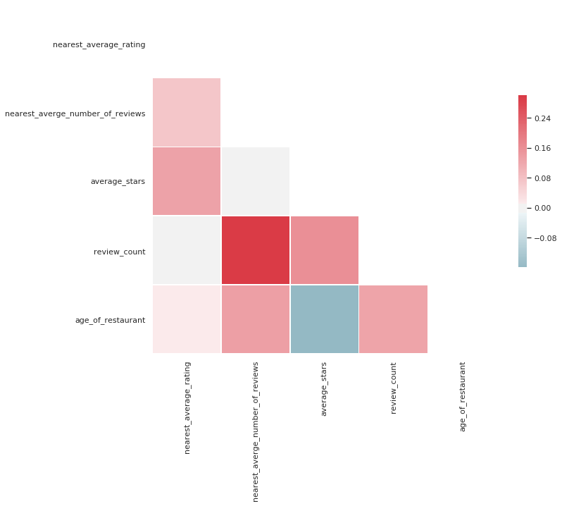

```python
# Code from https://seaborn.pydata.org/examples/many_pairwise_correlations.html
sns.set(style="white")

# Compute the correlation matrix
corr = df.corr()

# Generate a mask for the upper triangle
mask = np.zeros_like(corr, dtype=np.bool)
mask[np.triu_indices_from(mask)] = True

# Set up the matplotlib figure
f, ax = plt.subplots(figsize=(11, 9))

# Generate a custom diverging colormap
cmap = sns.diverging_palette(220, 10, as_cmap=True)

# Draw the heatmap with the mask and correct aspect ratio
sns.heatmap(corr, mask=mask, cmap=cmap, vmax=.3, center=0,
            square=True, linewidths=.5, cbar_kws={"shrink": .5})
```

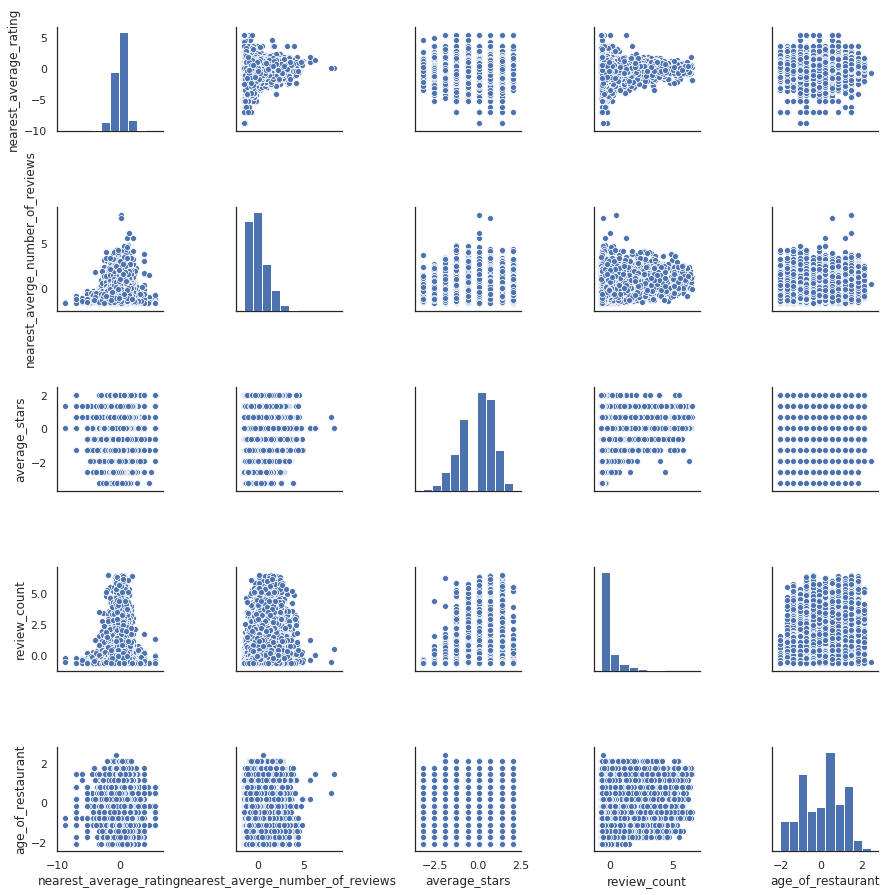

```python
sns.pairplot(df)
```

## 2. Baseline Modeling

I am using undersampled data to test logistic regression and decsion tree models. Other estimators don't perform good. The pipelines transform train and test set separately. I tried to use three forms of textual features.

- Simple TF-IDF
- Bag of Words
- Bag of Words with IDF Penality

```python
from sklearn.metrics import classification_report, confusion_matrix,roc_auc_score,average_precision_score
from sklearn.tree import DecisionTreeClassifier
from sklearn.neighbors import KNeighborsClassifier
from sklearn.naive_bayes import GaussianNB
from sklearn.linear_model import LogisticRegression
from sklearn.svm import SVC, LinearSVC
from sklearn.feature_selection import SelectFromModel
from sklearn.metrics import accuracy_score
from sklearn.preprocessing import StandardScaler
from sklearn.impute import SimpleImputer
from sklearn.pipeline import Pipeline
from sklearn.preprocessing import Normalizer
```

```python
# these are the first 5 features
first_5 = ["nearest_average_rating", "nearest_averge_number_of_reviews", "average_stars", "review_count", "age_of_restaurant"]
first_5
```

```
['nearest_average_rating',
 'nearest_averge_number_of_reviews',
 'average_stars',
 'review_count',
 'age_of_restaurant']
```

```python
# these are the remaining
restaurants_vectorizer_bow2.get_feature_names()[:10]
```

```
['ability',
 'able',
 'absolute',
 'absolutely',
 'ac',
 'accent',
 'accept',
 'acceptable',
 'access',
 'accessible']
```

```python
# combine the features
all_the_features =  first_5 + list(restaurants_vectorizer_bow2.get_feature_names())
len(all_the_features)
```

```
3218
```

```python
def estimate(model_type, X_train, y_train, X_test, y_test, penalty, C):
    if(model_type == "logistic_regression"):
        model = LogisticRegression(penalty='l2', C=0.1)
    elif(model_type == "decision_tree"):
        model = DecisionTree()

    model.fit(X_train, y_train)
    y_pred =model.predict(X_test)
    y_pred_train = model.predict(X_train)

    print('\n Confusion Matrix')
    print(pd.crosstab(y_test, y_pred, rownames=['True'], colnames=['Predicted']))
    print(classification_report(y_test, y_pred))
    print("ROC-AUC", roc_auc_score(y_test, y_pred))
    print("PR-AUC-Score", average_precision_score(y_test, y_pred))
    print("Test Accuracy: ", accuracy_score(y_test, y_pred))
    print("Train Accuracy: ", accuracy_score(y_train, y_pred_train))
    return model
```

```python
def analyze_cofficeints(feature_names, coeffs):
    print("Most positive cofficeints\n(contribute positively to restaurants closure)")
    print()
    sorted_features = np.argsort(coeffs).ravel()[::-1]
    for i in range(14):
        print(feature_names[sorted_features[i]], end=",")
    print()
    print("\nMost negative cofficeints\n(contribute negatively to restaurants closure)")
    print()
    sorted_features = np.argsort(coeffs).ravel()
    for i in range(15):
        print(feature_names[sorted_features[i]],end=",")
```

### A. Simple TF-IDF Model

The preprocessing is done in the previous section in this way. I split the train and test sets before a and converted each of them to tfidf vectors. The same vocabulary is used for both. Doing a train-test split after tfidf vectorization creates a weak model because test-set data will leak to the train-set.

```python
pipeline = Pipeline([
                     ('dtf', DistanceTransformer()),
                     ('imputer', SimpleImputer(strategy="mean")),
                     ("scale-normalize", CustomNormalizer())])
# ("lsa", LSA())
```

```python
X_train_tf_idf_t = pipeline.fit_transform(X_train_tf_idf)
```

```python
X_test_tf_idf_t = pipeline.fit_transform(X_test_tf_idf)
```

```python
# logistic regression
model = logistic_regression_exp(X_train_tf_idf_t,  y_train_tf_idf, X_test_tf_idf_t, y_test_tf_idf, 'l2', 0.1 )
analyze_cofficeints(all_the_features, model.coef_)
```

```
 Confusion Matrix
Predicted     0     1
True
0          1695   795
1           771  1719
              precision    recall  f1-score   support

           0       0.69      0.68      0.68      2490
           1       0.68      0.69      0.69      2490

   micro avg       0.69      0.69      0.69      4980
   macro avg       0.69      0.69      0.69      4980
weighted avg       0.69      0.69      0.69      4980

ROC-AUC 0.6855421686746987
PR-AUC-Score 0.6268683325186186
Test Accuracy:  0.6855421686746987
Train Accuracy:  0.7027668383318186
Most positive cofficeints
(contribute positively to restaurants closure)

theme,overwhelming,groupon,veg,clear,mention,burst,si,pretend,runny,resturant,budget,enthusiastic,wind,

Most negative cofficeints
(contribute negatively to restaurants closure)

locally,fashion,option,st,curious,allow,separate,bus,stool,management,dressing,route,vs,limited,els,
```

#### Decision Trees

```python
dt_model = DecisionTreeClassifier()
dt_model.fit(X_train_tf_idf_t, y_train_tf_idf)
y_pred = dt_model.predict(X_test_tf_idf_t)
print('\n Confusion Matrix')
print(pd.crosstab(y_test_tf_idf, y_pred, rownames=['True'], colnames=['Predicted']))
print(classification_report(y_test_tf_idf, y_pred))
print("ROC-AUC", roc_auc_score(y_test_tf_idf, y_pred))
print("PR-AUC-Score", average_precision_score(y_test_tf_idf, y_pred))
print("Test Accuracy: ", accuracy_score(y_test_tf_idf, y_pred))
```

```
 Confusion Matrix
Predicted     0     1
True
0          1430  1060
1          1097  1393
              precision    recall  f1-score   support

           0       0.57      0.57      0.57      2490
           1       0.57      0.56      0.56      2490

   micro avg       0.57      0.57      0.57      4980
   macro avg       0.57      0.57      0.57      4980
weighted avg       0.57      0.57      0.57      4980

ROC-AUC 0.5668674698795181
PR-AUC-Score 0.5379724360139293
Test Accuracy:  0.5668674698795181
```

```python
sorted_features = np.argsort(dt_model.feature_importances_)[::-1]
for i in range(20):
    print(all_the_features[sorted_features[i]], end=",")
```

```
curious,locally,fashion,golf,theme,separate,friend,st,pizza,tikka,fond,pretend,option,groupon,frequent,bus,overwhelming,newly,appreciate,opposite,
```

### B. Bag of Words Model

In the preprocessing step, the bag of words vectors were created for all the data. And then the data is split into train and test set. Unlike the tfidf transformation, bag of words vectorization don't leak data. Every business has its own reviews and words are counted based on those reviews. Coupus-wide information like inverse document frequency is not used.

```python
pipeline = Pipeline([
                     ('dtf', DistanceTransformer()),
                     ('imputer', SimpleImputer(strategy="mean")),
                     ("scale-normalize", CustomNormalizer())])
# ("lsa", LSA())
```

```python
X_train_bow_t = pipeline.fit_transform(X_train_bow[:, 1:])
X_test_bow_t = pipeline.fit_transform(X_test_bow[:, 1:])
```

```python
y_train_bow = y_train_bow.ravel()
y_test_bow = y_test_bow.ravel()
```

#### Logistic Regression

```python
X_train_bow[:, 6].toarray()
```

```
array([[0.],
       [0.],
       [0.],
       ...,
       [0.],
       [0.],
       [0.]])
```

```python
logistic_model = LogisticRegression(penalty='l2', C=0.01)
logistic_model.fit(X_train_bow_t, y_train_bow)
y_pred = logistic_model.predict(X_test_bow_t)
y_pred_train = logistic_model.predict(X_train_bow_t)
print('\n Confusion Matrix')
print(pd.crosstab(y_test_bow, y_pred, rownames=['True'], colnames=['Predicted']))
print(classification_report(y_test_bow, y_pred))
print("ROC-AUC", roc_auc_score(y_test_bow, y_pred))
print("PR-AUC-Score", average_precision_score(y_test_bow, y_pred))
print("Test Accuracy: ", accuracy_score(y_test_bow, y_pred))
print("Train Accuracy: ", accuracy_score(y_train_bow, y_pred_train))
```

```
 Confusion Matrix
Predicted   0.0   1.0
True
0.0        1185  1294
1.0         445  2034
              precision    recall  f1-score   support

         0.0       0.73      0.48      0.58      2479
         1.0       0.61      0.82      0.70      2479

   micro avg       0.65      0.65      0.65      4958
   macro avg       0.67      0.65      0.64      4958
weighted avg       0.67      0.65      0.64      4958

ROC-AUC 0.6492537313432836
PR-AUC-Score 0.591220579793341
Test Accuracy:  0.6492537313432836
Train Accuracy:  0.7046600766592698
```

```python
print("Most positive cofficeints\n(contribute positively to restaurants closure)")
print()
sorted_features = np.argsort(logistic_model.coef_).ravel()[::-1]
for i in range(10):
    print(all_the_features[sorted_features[i]], end=",")
print()
print("\nMost negative cofficeints\n(contribute negatively to restaurants closure)")
print()
sorted_features = np.argsort(logistic_model.coef_).ravel()
for i in range(10):
    print(all_the_features[sorted_features[i]],end=",")
```

```
Most positive cofficeints
(contribute positively to restaurants closure)

good,place,age_of_restaurant,nearest_averge_number_of_reviews,menu,like,restaurant,try,owner,groupon,

Most negative cofficeints
(contribute negatively to restaurants closure)

review_count,location,fast,pizza,employee,customer,drive,manager,rude,store,
```

#### Decision Tree

```python
dt_model = DecisionTreeClassifier()
dt_model.fit(X_train_bow_t, y_train_bow)
y_pred = dt_model.predict(X_test_bow_t)
print('\n Confusion Matrix')
print(pd.crosstab(y_test_bow, y_pred, rownames=['True'], colnames=['Predicted']))
print(classification_report(y_test_bow, y_pred))
print("ROC-AUC", roc_auc_score(y_test_bow, y_pred))
print("PR-AUC-Score", average_precision_score(y_test_bow, y_pred))
print("Test Accuracy: ", accuracy_score(y_test_bow, y_pred))
```

```
 Confusion Matrix
Predicted  0.0   1.0
True
0.0        156  2323
1.0        114  2365
              precision    recall  f1-score   support

         0.0       0.58      0.06      0.11      2479
         1.0       0.50      0.95      0.66      2479

   micro avg       0.51      0.51      0.51      4958
   macro avg       0.54      0.51      0.39      4958
weighted avg       0.54      0.51      0.39      4958

ROC-AUC 0.508471157724889
PR-AUC-Score 0.5042735256013999
Test Accuracy:  0.508471157724889
```

```python
sorted_features = np.argsort(dt_model.feature_importances_)[::-1]
for i in range(20):
    print(all_the_features[sorted_features[i]], end=",")
```

```
good,place,food,age_of_restaurant,nearest_averge_number_of_reviews,review_count,like,service,menu,restaurant,staff,fast,great,average_stars,eat,try,friendly,day,location,chicken,
```

### C. Bag of Words with IDF Penalty

I applied some penalty to the training set based on class labels. For each word, its term frequency is multiplied by the inverse document frequency of the word in the opposite class. The same penalty couldn't not applied to test-set because I can not use test-set class labels for feature transformation because in the real world class label is something to be predicted by a model. A model don't have prior information about the class labels

```python
pipeline = Pipeline([('idf', IDFPenalty()),
                     ('dtf', DistanceTransformer()),
                     ('imputer', SimpleImputer(strategy="mean")),
                     ("scale-normalize", CustomNormalizer())])
# ("lsa", LSA())
```

```python
# transform only train-set because the test-set cannot contain the target class
X_train_bow_penalized_t = pipeline.fit_transform(X_train_bow)
```

```python
y_train_bow = y_train_bow.ravel()
y_test_bow = y_test_bow.ravel()
```

#### Logistic Regression

```python
logistic_model = LogisticRegression(penalty='l2', C=0.01)
logistic_model.fit(X_train_bow_penalized_t, y_train_bow)
y_pred = logistic_model.predict(X_test_bow_t)
y_pred_train = logistic_model.predict(X_train_bow_penalized_t)
print('\n Confusion Matrix')
print(pd.crosstab(y_test_bow, y_pred, rownames=['True'], colnames=['Predicted']))
print(classification_report(y_test_bow, y_pred))
print("ROC-AUC", roc_auc_score(y_test_bow, y_pred))
print("PR-AUC-Score", average_precision_score(y_test_bow, y_pred))
print("Test Accuracy: ", accuracy_score(y_test_bow, y_pred))
print("Train Accuracy: ", accuracy_score(y_train_bow, y_pred_train))
```

```
 Confusion Matrix
Predicted   0.0   1.0
True
0.0        1058  1421
1.0         365  2114
              precision    recall  f1-score   support

         0.0       0.74      0.43      0.54      2479
         1.0       0.60      0.85      0.70      2479

   micro avg       0.64      0.64      0.64      4958
   macro avg       0.67      0.64      0.62      4958
weighted avg       0.67      0.64      0.62      4958

ROC-AUC 0.6397741024606696
PR-AUC-Score 0.5835876810754896
Test Accuracy:  0.6397741024606697
Train Accuracy:  0.7159572321968933
```

```python
print("Most positive cofficeints\n(contribute positively to restaurants closure)")
print()
sorted_features = np.argsort(logistic_model.coef_).ravel()[::-1]
for i in range(14):
    print(all_the_features[sorted_features[i]], end=",")
print()
print("\nMost negative cofficeints\n(contribute negatively to restaurants closure)")
print()
sorted_features = np.argsort(logistic_model.coef_).ravel()
for i in range(15):
    print(all_the_features[sorted_features[i]],end=",")
```

```
Most positive cofficeints
(contribute positively to restaurants closure)

good,place,age_of_restaurant,nearest_averge_number_of_reviews,groupon,menu,owner,like,restaurant,wine,try,dish,food,buffet,

Most negative cofficeints
(contribute negatively to restaurants closure)

review_count,location,fast,employee,rude,pizza,customer,manager,mcdonald,drive,store,busy,subway,line,quick,
```

#### Decsion Tree

```python
dt_model = DecisionTreeClassifier()
dt_model.fit(X_train_bow_penalized_t, y_train_bow)
y_pred = dt_model.predict(X_test_bow_t)
print('\n Confusion Matrix')
print(pd.crosstab(y_test_bow, y_pred, rownames=['True'], colnames=['Predicted']))
print(classification_report(y_test_bow, y_pred))
print("ROC-AUC", roc_auc_score(y_test_bow, y_pred))
print("PR-AUC-Score", average_precision_score(y_test_bow, y_pred))
print("Test Accuracy: ", accuracy_score(y_test_bow, y_pred))
```

```
 Confusion Matrix
Predicted  0.0   1.0
True
0.0        221  2258
1.0        213  2266
              precision    recall  f1-score   support

         0.0       0.51      0.09      0.15      2479
         1.0       0.50      0.91      0.65      2479

   micro avg       0.50      0.50      0.50      4958
   macro avg       0.51      0.50      0.40      4958
weighted avg       0.51      0.50      0.40      4958

ROC-AUC 0.5016135538523598
PR-AUC-Score 0.5008082035874111
Test Accuracy:  0.5016135538523598
```

```python
sorted_features = np.argsort(dt_model.feature_importances_)[::-1]
for i in range(20):
    print(all_the_features[sorted_features[i]], end=",")
```

```
good,place,food,age_of_restaurant,nearest_averge_number_of_reviews,menu,like,review_count,restaurant,nearest_average_rating,average_stars,meal,service,manager,couple,staff,location,definitely,store,check,
```

## 3. Ensembles

The baseline models performed better with the tfidf features. The bag of words features are not bad. I choose the bag of words features because its results are interpretable and doing gridsearchcv is possible without data leakage. Next I will try to use ensemble models

### A. Bag of Words Model

#### Random Forest

```python
from sklearn.ensemble import RandomForestClassifier
rfc_model = RandomForestClassifier(max_depth=50, n_estimators=900,  min_samples_leaf=15, n_jobs=-1)
rfc_model.fit(X_train_bow_t, y_train_bow)
y_pred = rfc_model.predict(X_test_bow_t)
y_pred_train = rfc_model.predict(X_train_bow_t)
print('\n Confusion Matrix')
print(pd.crosstab(y_test_bow, y_pred, rownames=['True'], colnames=['Predicted']))
print(classification_report(y_test_bow, y_pred))
print("ROC-AUC", roc_auc_score(y_test_bow, y_pred))
print("PR-AUC-Score", average_precision_score(y_test_bow, y_pred))
print("Test Accuracy: ", accuracy_score(y_test_bow, y_pred))
print("Train Accuracy: ", accuracy_score(y_train_bow, y_pred_train))
```

```
 Confusion Matrix
Predicted  0.0   1.0
True
0.0        189  2290
1.0         81  2398
              precision    recall  f1-score   support

         0.0       0.70      0.08      0.14      2479
         1.0       0.51      0.97      0.67      2479

   micro avg       0.52      0.52      0.52      4958
   macro avg       0.61      0.52      0.40      4958
weighted avg       0.61      0.52      0.40      4958

ROC-AUC 0.5217829770068576
PR-AUC-Score 0.5111424016344805
Test Accuracy:  0.5217829770068576
Train Accuracy:  0.9666633044179948
```

#### LightGBM

```python
import lightgbm as lgb
lgb_train_data = lgb.Dataset(X_train_bow_t,label=y_train_bow)

params = {}
params['learning_rate'] = 0.003
params['boosting_type'] = 'gbdt'
params['objective'] = 'binary'
params['metric'] = 'binary_error'
params['sub_feature'] = 0.5
params['num_leaves'] = 150
params['min_data'] = 50
params['max_depth'] = 30

#training our model using light gbm
num_round=1000
lgbm_model = lgb.train(params, lgb_train_data, num_round)

y_pred = lgbm_model.predict(X_test_bow_t)
#converting probabilities into 0 or 1
for i in range(0, len(y_test_bow)):
    if y_pred[i] >= .5:
        y_pred [i] = 1
    else:
        y_pred [i] = 0

y_pred_train = lgbm_model.predict(X_train_bow_t)
#converting probabilities into 0 or 1
for i in range(0,len(y_train_bow)):
    if y_pred_train[i] >= .5:
        y_pred_train [i] = 1
    else:
        y_pred_train [i] = 0
print('\n Confusion Matrix')
print(pd.crosstab(y_test_bow, y_pred, rownames=['True'], colnames=['Predicted']))
print(classification_report(y_test_bow, y_pred))
print("ROC-AUC", roc_auc_score(y_test_bow, y_pred))
print("PR-AUC-Score", average_precision_score(y_test_bow, y_pred))
print("Test Accuracy: ", accuracy_score(y_test_bow, y_pred))
print("Train Accuracy: ", accuracy_score(y_train_bow, y_pred_train))
```

```
 Confusion Matrix
Predicted  0.0   1.0
True
0.0         89  2390
1.0         43  2436
              precision    recall  f1-score   support

         0.0       0.67      0.04      0.07      2479
         1.0       0.50      0.98      0.67      2479

   micro avg       0.51      0.51      0.51      4958
   macro avg       0.59      0.51      0.37      4958
weighted avg       0.59      0.51      0.37      4958

ROC-AUC 0.509277934651069
PR-AUC-Score 0.5046831845855789
Test Accuracy:  0.509277934651069
Train Accuracy:  0.9862820254186
```

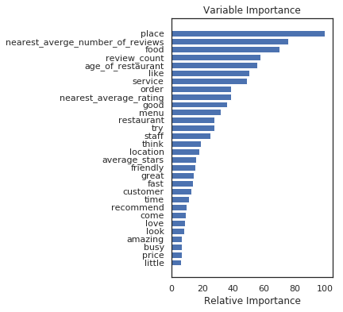

```python
feature_importance = lgbm_model.feature_importance()
# Make importances relative to max importance.
feature_importance = 100.0 * (feature_importance / feature_importance.max())
# argsort sorts from smallest to largest
sorted_idx = np.argsort(feature_importance)[-30:]
pos = np.arange(sorted_idx.shape[0]) + .9
# # use only one column of a 1 x 2 figure
plt.subplot(1, 2, 2)
# pos is the postion of the bars on the y axis
# feature_importance[sorted_idx] is the width of the bars
plt.barh(pos, feature_importance[sorted_idx], align='center')
plt.yticks(pos, np.array(all_the_features)[[sorted_idx]])
plt.xlabel('Relative Importance')
plt.title('Variable Importance')
plt.show()
# print("\nColumn headers\n\n",X.columns)
# print("\n Feature Importance", feature_importance)
# print("\nargsorted from smallest to largest\n\n",sorted_idx)
# print("\nColumn headers\n\n",X.columns[sorted_idx])
# print("\nRearranged accordingly\n\n",feature_importance[sorted_idx])
# print("\nPosition on the y axis\n\n", pos)
```

#### XGBoost

```python
from xgboost import XGBClassifier
xgboost_model = XGBClassifier()
xgboost_model.fit(X_train_bow_t, y_train_bow)
y_pred = xgboost_model.predict(X_test_bow_t)
y_pred_train = xgboost_model.predict(X_train_bow_t)
print('\n Confusion Matrix')
print(pd.crosstab(y_test_bow, y_pred, rownames=['True'], colnames=['Predicted']))
print(classification_report(y_test_bow, y_pred))
print("ROC-AUC", roc_auc_score(y_test_bow, y_pred))
print("PR-AUC-Score", average_precision_score(y_test_bow, y_pred))
print("Accuracy: ", accuracy_score(y_test_bow, y_pred))
print("Train Accuracy: ", accuracy_score(y_train_bow, y_pred_train))
```

```
 Confusion Matrix
Predicted  0.0   1.0
True
0.0        120  2359
1.0         53  2426
              precision    recall  f1-score   support

         0.0       0.69      0.05      0.09      2479
         1.0       0.51      0.98      0.67      2479

   micro avg       0.51      0.51      0.51      4958
   macro avg       0.60      0.51      0.38      4958
weighted avg       0.60      0.51      0.38      4958

ROC-AUC 0.5135135135135135
PR-AUC-Score 0.5068513654720551
Accuracy:  0.5135135135135135
Train Accuracy:  0.9749848698809764
```

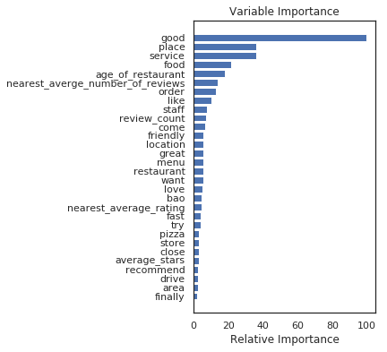

```python
feature_importance = xgboost_model.feature_importances_
# Make importances relative to max importance.
feature_importance = 100.0 * (feature_importance / feature_importance.max())
# argsort sorts from smallest to largest
sorted_idx = np.argsort(feature_importance)[-30:]
pos = np.arange(sorted_idx.shape[0]) + .9
# # use only one column of a 1 x 2 figure
plt.subplot(1, 2, 2)
# pos is the postion of the bars on the y axis
# feature_importance[sorted_idx] is the width of the bars
plt.barh(pos, feature_importance[sorted_idx], align='center')
plt.yticks(pos, np.array(all_the_features)[[sorted_idx]])
plt.xlabel('Relative Importance')
plt.title('Variable Importance')
plt.show()
```

### C. Bag of Words with IDF Penalty

#### Random Forest

```python
from sklearn.ensemble import RandomForestClassifier
rfc_model = RandomForestClassifier(max_depth=50, n_estimators=900,  min_samples_leaf=15, n_jobs=-1)
rfc_model.fit(X_train_bow_penalized_t, y_train_bow)
y_pred = rfc_model.predict(X_test_bow_t)
y_pred_train = rfc_model.predict(X_train_bow_penalized_t)
print('\n Confusion Matrix')
print(pd.crosstab(y_test_bow, y_pred, rownames=['True'], colnames=['Predicted']))
print(classification_report(y_test_bow, y_pred))
print("ROC-AUC", roc_auc_score(y_test_bow, y_pred))
print("PR-AUC-Score", average_precision_score(y_test_bow, y_pred))
print("Test Accuracy: ", accuracy_score(y_test_bow, y_pred))
print("Train Accuracy: ", accuracy_score(y_train_bow, y_pred_train))
```

```
 Confusion Matrix
Predicted  0.0   1.0
True
0.0        164  2315
1.0         76  2403
              precision    recall  f1-score   support

         0.0       0.68      0.07      0.12      2479
         1.0       0.51      0.97      0.67      2479

   micro avg       0.52      0.52      0.52      4958
   macro avg       0.60      0.52      0.39      4958
weighted avg       0.60      0.52      0.39      4958

ROC-AUC 0.5177490923759581
PR-AUC-Score 0.5090400739676615
Test Accuracy:  0.517749092375958
Train Accuracy:  0.9746318337704256
```

#### LightGBM

```python
import lightgbm as lgb
lgb_train_data = lgb.Dataset(X_train_bow_penalized_t,label=y_train_bow)

params = {}
params['learning_rate'] = 0.003
params['boosting_type'] = 'gbdt'
params['objective'] = 'binary'
params['metric'] = 'binary_error'
params['sub_feature'] = 0.5
params['num_leaves'] = 150
params['min_data'] = 50
params['max_depth'] = 30

#training our model using light gbm
num_round=1000
lgbm_model = lgb.train(params, lgb_train_data, num_round)

y_pred = lgbm_model.predict(X_test_bow_t)
#converting probabilities into 0 or 1
for i in range(0, len(y_test_bow)):
    if y_pred[i] >= .5:
        y_pred [i] = 1
    else:
        y_pred [i] = 0

y_pred_train = lgbm_model.predict(X_train_bow_penalized_t)
#converting probabilities into 0 or 1
for i in range(0,len(y_train_bow)):
    if y_pred_train[i] >= .5:
        y_pred_train [i] = 1
    else:
        y_pred_train [i] = 0
print('\n Confusion Matrix')
print(pd.crosstab(y_test_bow, y_pred, rownames=['True'], colnames=['Predicted']))
print(classification_report(y_test_bow, y_pred))
print("ROC-AUC", roc_auc_score(y_test_bow, y_pred))
print("PR-AUC-Score", average_precision_score(y_test_bow, y_pred))
print("Test Accuracy: ", accuracy_score(y_test_bow, y_pred))
print("Train Accuracy: ", accuracy_score(y_train_bow, y_pred_train))
```

```
 Confusion Matrix
Predicted  0.0   1.0
True
0.0         79  2400
1.0         41  2438
              precision    recall  f1-score   support

         0.0       0.66      0.03      0.06      2479
         1.0       0.50      0.98      0.67      2479

   micro avg       0.51      0.51      0.51      4958
   macro avg       0.58      0.51      0.36      4958
weighted avg       0.58      0.51      0.36      4958

ROC-AUC 0.5076643807987091
PR-AUC-Score 0.503862290282607
Test Accuracy:  0.5076643807987091
Train Accuracy:  0.9907201936655236
```

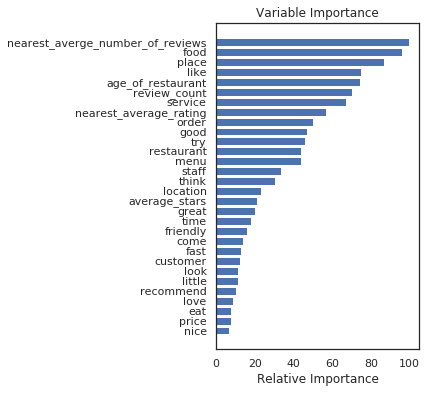

```python
feature_importance = lgbm_model.feature_importance()
# Make importances relative to max importance.
feature_importance = 100.0 * (feature_importance / feature_importance.max())
# argsort sorts from smallest to largest
sorted_idx = np.argsort(feature_importance)[-30:]
pos = np.arange(sorted_idx.shape[0]) + .9
# # use only one column of a 1 x 2 figure
plt.subplot(1, 2, 2)
# pos is the postion of the bars on the y axis
# feature_importance[sorted_idx] is the width of the bars
plt.barh(pos, feature_importance[sorted_idx], align='center')
plt.yticks(pos, np.array(all_the_features)[[sorted_idx]])
plt.xlabel('Relative Importance')
plt.title('Variable Importance')
plt.show()
# print("\nColumn headers\n\n",X.columns)
# print("\n Feature Importance", feature_importance)
# print("\nargsorted from smallest to largest\n\n",sorted_idx)
# print("\nColumn headers\n\n",X.columns[sorted_idx])
# print("\nRearranged accordingly\n\n",feature_importance[sorted_idx])
# print("\nPosition on the y axis\n\n", pos)
```

#### XGBoost

```python
from xgboost import XGBClassifier
xgboost_model = XGBClassifier()
xgboost_model.fit(X_train_bow_penalized_t, y_train_bow)
y_pred = xgboost_model.predict(X_test_bow_t)
y_pred_train = xgboost_model.predict(X_train_bow_penalized_t)
print('\n Confusion Matrix')
print(pd.crosstab(y_test_bow, y_pred, rownames=['True'], colnames=['Predicted']))
print(classification_report(y_test_bow, y_pred))
print("ROC-AUC", roc_auc_score(y_test_bow, y_pred))
print("PR-AUC-Score", average_precision_score(y_test_bow, y_pred))
print("Accuracy: ", accuracy_score(y_test_bow, y_pred))
print("Train Accuracy: ", accuracy_score(y_train_bow, y_pred_train))
```

```
 Confusion Matrix
Predicted  0.0   1.0
True
0.0        108  2371
1.0         56  2423
              precision    recall  f1-score   support

         0.0       0.66      0.04      0.08      2479
         1.0       0.51      0.98      0.67      2479

   micro avg       0.51      0.51      0.51      4958
   macro avg       0.58      0.51      0.37      4958
weighted avg       0.58      0.51      0.37      4958

ROC-AUC 0.5104881000403388
PR-AUC-Score 0.5053009316641095
Accuracy:  0.5104881000403388
Train Accuracy:  0.9837603389146661
```

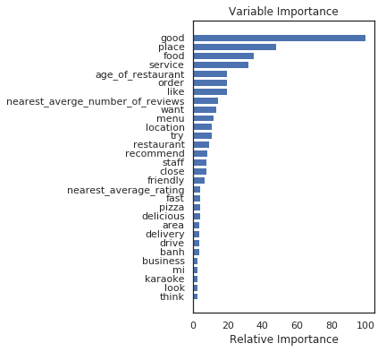

```python
feature_importance = xgboost_model.feature_importances_
# Make importances relative to max importance.
feature_importance = 100.0 * (feature_importance / feature_importance.max())
# argsort sorts from smallest to largest
sorted_idx = np.argsort(feature_importance)[-30:]
pos = np.arange(sorted_idx.shape[0]) + .9
# # use only one column of a 1 x 2 figure
plt.subplot(1, 2, 2)
# pos is the postion of the bars on the y axis
# feature_importance[sorted_idx] is the width of the bars
plt.barh(pos, feature_importance[sorted_idx], align='center')
plt.yticks(pos, np.array(all_the_features)[[sorted_idx]])
plt.xlabel('Relative Importance')
plt.title('Variable Importance')
plt.show()
```

XGBoost didn't select average stars, as an important feature.

IDF penality didn't increase the performance. Therefore I will only tune models using the bag of words model

## 4. Parameter Tuning and Testing

### Best Parameters for Logistic Regression

```python
pipeline = Pipeline([
                     ('dtf', DistanceTransformer()),
                     ('imputer', SimpleImputer(strategy="mean")),
                     ("scale-normalize", CustomNormalizer()),
    ("logistic", LogisticRegression())])
```

```python
from sklearn.model_selection import ParameterGrid, GridSearchCV
param_grid = {'logistic__C': [0.1, 0.2, 0.25, 0.5, 1.0, 1.25,1.5],
                   'logistic__penalty' :['l2']
                  }
logistic_search = GridSearchCV(pipeline, param_grid, iid=False, cv=3,
                      return_train_score=True, n_jobs=-1)
logistic_search.fit(X_train_bow[:, 1:], y_train_bow)
print("Best parameter (CV score=%0.3f):" % logistic_search.best_score_)
print(logistic_search.best_params_)
```

```
Best parameter (CV score=0.930):
{'logistic__C': 1.5, 'logistic__penalty': 'l2'}
```

```python
logistic_search.cv_results_
```

[output not shown]

```python
y_pred = logistic_search.predict(X_test_bow[:,1:])
y_pred_train = logistic_search.predict(X_train_bow[:,1:])
print('\n Confusion Matrix')
print(pd.crosstab(y_test_bow, y_pred, rownames=['True'], colnames=['Predicted']))
print(classification_report(y_test_bow, y_pred))
print("ROC-AUC", roc_auc_score(y_test_bow, y_pred))
print("PR-AUC-Score", average_precision_score(y_test_bow, y_pred))
print("Test Accuracy: ", accuracy_score(y_test_bow, y_pred))
print("Train Accuracy: ", accuracy_score(y_train_bow, y_pred_train))
```

```
 Confusion Matrix
Predicted  0.0   1.0
True
0.0        157  2322
1.0         57  2422
              precision    recall  f1-score   support

         0.0       0.73      0.06      0.12      2479
         1.0       0.51      0.98      0.67      2479

   micro avg       0.52      0.52      0.52      4958
   macro avg       0.62      0.52      0.39      4958
weighted avg       0.62      0.52      0.39      4958

ROC-AUC 0.5201694231544978
PR-AUC-Score 0.5102972898145433
Test Accuracy:  0.5201694231544978
Train Accuracy:  0.9643937865644543
```

Logistic Regression cross validation score shows gave unusually large scores. The variance across folds is small. It didn't remove overfitting because the test score is only 0.52

## 5. Separating Bag of Words and Dense Features

The bag of words contain more than 3000 features. Let me try to see their performance alone.

### A. Only Bag of Words

#### Logistic Regression

```python
X_train_bow_t
```

```
<19828x3218 sparse matrix of type '<class 'numpy.float64'>'
	with 3661756 stored elements in COOrdinate format>
```

```python
logistic_model = LogisticRegression(penalty='l2', C=0.01)
logistic_model.fit(X_train_bow_t.tocsr()[:,5:], y_train_bow)
y_pred = logistic_model.predict(X_test_bow_t.tocsr()[:,5:])
y_pred_train = logistic_model.predict(X_train_bow_t.tocsr()[:,5:])
print('\n Confusion Matrix')
print(pd.crosstab(y_test_bow, y_pred, rownames=['True'], colnames=['Predicted']))
print(classification_report(y_test_bow, y_pred))
print("ROC-AUC", roc_auc_score(y_test_bow, y_pred))
print("PR-AUC-Score", average_precision_score(y_test_bow, y_pred))
print("Test Accuracy: ", accuracy_score(y_test_bow, y_pred))
print("Train Accuracy: ", accuracy_score(y_train_bow, y_pred_train))
```

```
 Confusion Matrix
Predicted  0.0   1.0
True
0.0        524  1955
1.0        197  2282
              precision    recall  f1-score   support

         0.0       0.73      0.21      0.33      2479
         1.0       0.54      0.92      0.68      2479

   micro avg       0.57      0.57      0.57      4958
   macro avg       0.63      0.57      0.50      4958
weighted avg       0.63      0.57      0.50      4958

ROC-AUC 0.5659540137152077
PR-AUC-Score 0.5355220814958943
Test Accuracy:  0.5659540137152077
Train Accuracy:  0.8224732701230583
```

```python
only_bow = restaurants_vectorizer_bow2.get_feature_names()
print("Most positive cofficeints\n(contribute positively to restaurants closure)")
print()
sorted_features = np.argsort(logistic_model.coef_).ravel()[::-1]
for i in range(15):
    print(only_bow[sorted_features[i]], end=",")
print("\n\nThe Coefficients\n")
print(logistic_model.coef_.ravel()[sorted_features][:10])
print()
print("\nMost negative cofficeints\n(contribute negatively to restaurants closure)")
print()
sorted_features = np.argsort(logistic_model.coef_).ravel()
for i in range(15):
    print(only_bow[sorted_features[i]],end=",")
print("\n\nThe Coefficients\n")
print(logistic_model.coef_.ravel()[sorted_features][:10])
```

```
Most positive cofficeints
(contribute positively to restaurants closure)

good,place,menu,like,owner,groupon,wine,think,restaurant,food,buffet,try,dish,close,chef,

The Coefficients

[0.81393215 0.58511551 0.31478528 0.31078144 0.28540003 0.2828254
 0.26410421 0.25742669 0.25630403 0.24164668]


Most negative cofficeints
(contribute negatively to restaurants closure)

location,fast,pizza,customer,employee,manager,busy,staff,drive,rude,service,quick,line,store,minute,

The Coefficients

[-0.50127141 -0.43079071 -0.40974834 -0.39741495 -0.37435773 -0.35970583
 -0.33697503 -0.33605823 -0.33367563 -0.32860477]
```

The bag of words model has 56% accuracy on the test set. The words that contributed to restaurant closure are not negative words. According to the model people refer to those words to restaurants that will close. Words like location, fast, pizza, customer, staff, service seem positive words which helped restaurants stay in the market. Restricting the reviews to small time might help improve the model

#### XGBoost

```python
from xgboost import XGBClassifier
xgboost_model = XGBClassifier()
xgboost_model.fit(X_train_bow[:,6:], y_train_bow)
y_pred = xgboost_model.predict(X_test_bow[:,6:])
y_pred_train = xgboost_model.predict(X_train_bow[:,6:])

print('\n Confusion Matrix')
print(pd.crosstab(y_test_bow, y_pred, rownames=['True'], colnames=['Predicted']))
print(classification_report(y_test_bow, y_pred))
print("ROC-AUC", roc_auc_score(y_test_bow, y_pred))
print("PR-AUC-Score", average_precision_score(y_test_bow, y_pred))
print("Test Accuracy: ", accuracy_score(y_test_bow, y_pred))
```

```
 Confusion Matrix
Predicted  0.0   1.0
True
0.0         68  2411
1.0         56  2423
              precision    recall  f1-score   support

         0.0       0.55      0.03      0.05      2479
         1.0       0.50      0.98      0.66      2479

   micro avg       0.50      0.50      0.50      4958
   macro avg       0.52      0.50      0.36      4958
weighted avg       0.52      0.50      0.36      4958

ROC-AUC 0.5024203307785396
PR-AUC-Score 0.5012131695234592
Test Accuracy:  0.5024203307785398
```

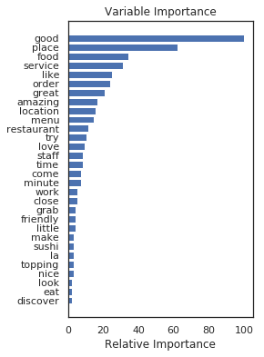

```python
feature_importance = xgboost_model.feature_importances_
# Make importances relative to max importance.
feature_importance = 100.0 * (feature_importance / feature_importance.max())
# argsort sorts from smallest to largest
sorted_idx = np.argsort(feature_importance)[-30:]
pos = np.arange(sorted_idx.shape[0]) + .9
# # use only one column of a 1 x 2 figure
plt.subplot(1, 2, 2)
# pos is the postion of the bars on the y axis
# feature_importance[sorted_idx] is the width of the bars
plt.barh(pos, feature_importance[sorted_idx], align='center')
plt.yticks(pos, np.array(only_bow)[[sorted_idx]])
plt.xlabel('Relative Importance')
plt.title('Variable Importance')
plt.show()
```

The words are similar to the onces obtained before. More research is required to know why these words are good predictors.

## Applying LSA

Let us see if the bow model can be improved by applying Latent Sematic Analyisis. The LSA class is able to fit and transform LSA on the training set and use it to transform the test set

```python
pipeline = Pipeline([
                     ('dtf', DistanceTransformer()),
                     ('imputer', SimpleImputer(strategy="mean")),
                    ("lsa", LSA(dim=500)),
                    ("scale-normalize", CustomNormalizer())
                ])
```

```python
X_train_bow_lsa_t = pipeline.fit_transform(X_train_bow[:, 1:])
X_test_bow_lsa_t = pipeline.transform(X_test_bow[:, 1:])
```

```
Percent variance captured by all components: 67.48031061879547
```

```python
logistic_model = LogisticRegression(penalty='l2', C=0.01)
logistic_model.fit(X_train_bow_lsa_t.tocsr()[:,5:], y_train_bow)
y_pred = logistic_model.predict(X_test_bow_lsa_t.tocsr()[:,5:])
y_pred_train = logistic_model.predict(X_train_bow_lsa_t.tocsr()[:,5:])
print('\n Confusion Matrix')
print(pd.crosstab(y_test_bow, y_pred, rownames=['True'], colnames=['Predicted']))
print(classification_report(y_test_bow, y_pred))
print("ROC-AUC", roc_auc_score(y_test_bow, y_pred))
print("PR-AUC-Score", average_precision_score(y_test_bow, y_pred))
print("Test Accuracy: ", accuracy_score(y_test_bow, y_pred))
print("Train Accuracy: ", accuracy_score(y_train_bow, y_pred_train))
```

```
 Confusion Matrix
Predicted   0.0   1.0
True
0.0        1670   809
1.0        1213  1266
              precision    recall  f1-score   support

         0.0       0.58      0.67      0.62      2479
         1.0       0.61      0.51      0.56      2479

   micro avg       0.59      0.59      0.59      4958
   macro avg       0.59      0.59      0.59      4958
weighted avg       0.59      0.59      0.59      4958

ROC-AUC 0.592174263816055
PR-AUC-Score 0.5562374062607833
Test Accuracy:  0.5921742638160549
Train Accuracy:  0.7894391769215251
```

LSA is able to increase the performance of logistic regression on the test-set with just 500 features. Overfitting is reduced as well. Next I will check the full model using only the 500 bag of words

```python
logistic_model = LogisticRegression(penalty='l2', C=0.01)
logistic_model.fit(X_train_bow_lsa_t.tocsr()[:,1:], y_train_bow)
y_pred = logistic_model.predict(X_test_bow_lsa_t.tocsr()[:,1:])
y_pred_train = logistic_model.predict(X_train_bow_lsa_t.tocsr()[:,1:])
print('\n Confusion Matrix')
print(pd.crosstab(y_test_bow, y_pred, rownames=['True'], colnames=['Predicted']))
print(classification_report(y_test_bow, y_pred))
print("ROC-AUC", roc_auc_score(y_test_bow, y_pred))
print("PR-AUC-Score", average_precision_score(y_test_bow, y_pred))
print("Test Accuracy: ", accuracy_score(y_test_bow, y_pred))
print("Train Accuracy: ", accuracy_score(y_train_bow, y_pred_train))
```

```
 Confusion Matrix
Predicted   0.0   1.0
True
0.0        1801   678
1.0        1074  1405
              precision    recall  f1-score   support

         0.0       0.63      0.73      0.67      2479
         1.0       0.67      0.57      0.62      2479

   micro avg       0.65      0.65      0.65      4958
   macro avg       0.65      0.65      0.64      4958
weighted avg       0.65      0.65      0.64      4958

ROC-AUC 0.6466317063331989
PR-AUC-Score 0.5989042474306983
Test Accuracy:  0.6466317063331989
Train Accuracy:  0.7954912245309663
```

The full model didn't imporve by much. Creating custom ensembles might be a good idea.

```python
from xgboost import XGBClassifier
xgboost_model = XGBClassifier()
xgboost_model.fit(X_train_bow_lsa_t[:,6:], y_train_bow)
y_pred = xgboost_model.predict(X_test_bow_lsa_t[:,6:])
y_pred_train = xgboost_model.predict(X_train_bow_lsa_t[:,6:])

print('\n Confusion Matrix')
print(pd.crosstab(y_test_bow, y_pred, rownames=['True'], colnames=['Predicted']))
print(classification_report(y_test_bow, y_pred))
print("ROC-AUC", roc_auc_score(y_test_bow, y_pred))
print("PR-AUC-Score", average_precision_score(y_test_bow, y_pred))
print("Test Accuracy: ", accuracy_score(y_test_bow, y_pred))
```

```
 Confusion Matrix
Predicted   0.0   1.0
True
0.0        1057  1422
1.0         583  1896
              precision    recall  f1-score   support

         0.0       0.64      0.43      0.51      2479
         1.0       0.57      0.76      0.65      2479

   micro avg       0.60      0.60      0.60      4958
   macro avg       0.61      0.60      0.58      4958
weighted avg       0.61      0.60      0.58      4958

ROC-AUC 0.5956030657523195
PR-AUC-Score 0.5546303232870398
Test Accuracy:  0.5956030657523195
```

There is a huge improvement for XGBoost. Let me check the full model

```python
from xgboost import XGBClassifier
xgboost_model = XGBClassifier()
xgboost_model.fit(X_train_bow_lsa_t[:,1:], y_train_bow)
y_pred = xgboost_model.predict(X_test_bow_lsa_t[:,1:])
y_pred_train = xgboost_model.predict(X_train_bow_lsa_t[:,1:])

print('\n Confusion Matrix')
print(pd.crosstab(y_test_bow, y_pred, rownames=['True'], colnames=['Predicted']))
print(classification_report(y_test_bow, y_pred))
print("ROC-AUC", roc_auc_score(y_test_bow, y_pred))
print("PR-AUC-Score", average_precision_score(y_test_bow, y_pred))
print("Test Accuracy: ", accuracy_score(y_test_bow, y_pred))
```

```
 Confusion Matrix
Predicted   0.0   1.0
True
0.0        1146  1333
1.0         429  2050
              precision    recall  f1-score   support

         0.0       0.73      0.46      0.57      2479
         1.0       0.61      0.83      0.70      2479

   micro avg       0.64      0.64      0.64      4958
   macro avg       0.67      0.64      0.63      4958
weighted avg       0.67      0.64      0.63      4958

ROC-AUC 0.6446147640177491
PR-AUC-Score 0.5876323577405811
Test Accuracy:  0.6446147640177491
```

XGBoost imporved from 50% to 64% percent

```python
import lightgbm as lgb
lgb_train_data = lgb.Dataset(X_train_bow_lsa_t,label=y_train_bow)

params = {}
params['learning_rate'] = 0.003
params['boosting_type'] = 'gbdt'
params['objective'] = 'binary'
params['metric'] = 'binary_error'
params['sub_feature'] = 0.5
params['num_leaves'] = 150
params['min_data'] = 50
params['max_depth'] = 30

#training our model using light gbm
num_round=1000
lgbm_model = lgb.train(params, lgb_train_data, num_round)

y_pred = lgbm_model.predict(X_test_bow_lsa_t)
#converting probabilities into 0 or 1
for i in range(0, len(y_test_bow)):
    if y_pred[i] >= .5:
        y_pred [i] = 1
    else:
        y_pred [i] = 0

y_pred_train = lgbm_model.predict(X_train_bow_lsa_t)
#converting probabilities into 0 or 1
for i in range(0,len(y_train_bow)):
    if y_pred_train[i] >= .5:
        y_pred_train [i] = 1
    else:
        y_pred_train [i] = 0
print('\n Confusion Matrix')
print(pd.crosstab(y_test_bow, y_pred, rownames=['True'], colnames=['Predicted']))
print(classification_report(y_test_bow, y_pred))
print("ROC-AUC", roc_auc_score(y_test_bow, y_pred))
print("PR-AUC-Score", average_precision_score(y_test_bow, y_pred))
print("Test Accuracy: ", accuracy_score(y_test_bow, y_pred))
print("Train Accuracy: ", accuracy_score(y_train_bow, y_pred_train))
```

```
 Confusion Matrix
Predicted   0.0   1.0
True
0.0        1244  1235
1.0         463  2016
              precision    recall  f1-score   support

         0.0       0.73      0.50      0.59      2479
         1.0       0.62      0.81      0.70      2479

   micro avg       0.66      0.66      0.66      4958
   macro avg       0.67      0.66      0.65      4958
weighted avg       0.67      0.66      0.65      4958

ROC-AUC 0.6575231948366277
PR-AUC-Score 0.5976827932299728
Test Accuracy:  0.6575231948366277
Train Accuracy:  0.9753883397216058
```

LightGBM is still overfitted but its test score is slightly higher than XBBoost

### B. Only Dense Features

The dense features include surrounding performance, I called them distance features. They are nearest_average_num_of_reviews, nearest_rating. The others are average_stars, review_count and age of restaurant

```python
logistic_model = LogisticRegression(penalty='l2', C=1.0)
logistic_model.fit(X_train_bow_t.tocsr()[:,:5], y_train_bow)
y_pred = logistic_model.predict(X_test_bow_t.tocsr()[:,:5])
y_pred_train = logistic_model.predict(X_train_bow_t.tocsr()[:,:5])
print('\n Confusion Matrix')
print(pd.crosstab(y_test_bow, y_pred, rownames=['True'], colnames=['Predicted']))
print(classification_report(y_test_bow, y_pred))
print("ROC-AUC", roc_auc_score(y_test_bow, y_pred))
print("PR-AUC-Score", average_precision_score(y_test_bow, y_pred))
print("Test Accuracy: ", accuracy_score(y_test_bow, y_pred))
print("Train Accuracy: ", accuracy_score(y_train_bow, y_pred_train))
```

```
 Confusion Matrix
Predicted   0.0   1.0
True
0.0        1564   915
1.0         886  1593
              precision    recall  f1-score   support

         0.0       0.64      0.63      0.63      2479
         1.0       0.64      0.64      0.64      2479

   micro avg       0.64      0.64      0.64      4958
   macro avg       0.64      0.64      0.64      4958
weighted avg       0.64      0.64      0.64      4958

ROC-AUC 0.636748688987495
PR-AUC-Score 0.586858318005215
Test Accuracy:  0.6367486889874949
Train Accuracy:  0.6555880572927174
```

```python
print("Most positive cofficeints\n(contribute positively to restaurants closure)")
print()
sorted_features = np.argsort(logistic_model.coef_).ravel()[::-1]
for i in range(5):
    print(first_5[sorted_features[i]], end=",")
print()
print("\nMost negative cofficeints\n(contribute negatively to restaurants closure)")
print()
sorted_features = np.argsort(logistic_model.coef_).ravel()
for i in range(5):
    print(first_5[sorted_features[i]],end=",")
print("\n\nThe Coefficients\n")
print(first_5)
print(logistic_model.coef_.ravel())
```

```
Most positive cofficeints
(contribute positively to restaurants closure)

age_of_restaurant,nearest_averge_number_of_reviews,average_stars,nearest_average_rating,review_count,

Most negative cofficeints
(contribute negatively to restaurants closure)

review_count,nearest_average_rating,average_stars,nearest_averge_number_of_reviews,age_of_restaurant,

The Coefficients

['nearest_average_rating', 'nearest_averge_number_of_reviews', 'average_stars', 'review_count', 'age_of_restaurant']
[ 0.04853778  0.50964896  0.15131915 -0.79238542  0.524393  ]
```

The age of a restaurant contributes the most to restaurant closure. It is interesting to see that the nereast average number of reviews contribute to closure while more reviews helps a restaurant to survive

```python
from xgboost import XGBClassifier

xgboost_model = XGBClassifier()
xgboost_model.fit(X_train_bow_t.tocsr()[:,:5], y_train_bow)
y_pred = xgboost_model.predict(X_test_bow_t.tocsr()[:,:5])
y_pred_train = xgboost_model.predict(X_train_bow_t.tocsr()[:,:5])

print('\n Confusion Matrix')
print(pd.crosstab(y_test_bow, y_pred, rownames=['True'], colnames=['Predicted']))
print(classification_report(y_test_bow, y_pred))
print("ROC-AUC", roc_auc_score(y_test_bow, y_pred))
print("PR-AUC-Score", average_precision_score(y_test_bow, y_pred))
print("Test Accuracy: ", accuracy_score(y_test_bow, y_pred))
```

```
 Confusion Matrix
Predicted   0.0   1.0
True
0.0        1585   894
1.0         784  1695
              precision    recall  f1-score   support

         0.0       0.67      0.64      0.65      2479
         1.0       0.65      0.68      0.67      2479

   micro avg       0.66      0.66      0.66      4958
   macro avg       0.66      0.66      0.66      4958
weighted avg       0.66      0.66      0.66      4958

ROC-AUC 0.6615570794675273
PR-AUC-Score 0.6057702779827959
Test Accuracy:  0.6615570794675272
```

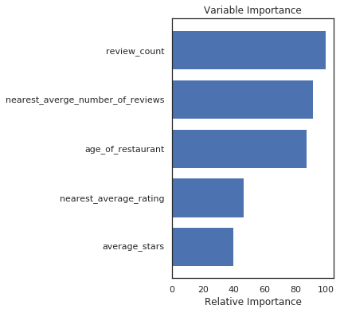

```python
feature_importance = xgboost_model.feature_importances_
# Make importances relative to max importance.
feature_importance = 100.0 * (feature_importance / feature_importance.max())
# argsort sorts from smallest to largest
sorted_idx = np.argsort(feature_importance)[-30:]
pos = np.arange(sorted_idx.shape[0]) + .9
# # use only one column of a 1 x 2 figure
plt.subplot(1, 2, 2)
# pos is the postion of the bars on the y axis
# feature_importance[sorted_idx] is the width of the bars
plt.barh(pos, feature_importance[sorted_idx], align='center')
plt.yticks(pos, np.array(all_the_features)[[sorted_idx]])
plt.xlabel('Relative Importance')
plt.title('Variable Importance')
plt.show()
```

```python
import lightgbm as lgb
lgb_train_data = lgb.Dataset(X_train_bow_t,label=y_train_bow)

params = {}
params['learning_rate'] = 0.003
params['boosting_type'] = 'gbdt'
params['objective'] = 'binary'
params['metric'] = 'binary_error'
params['sub_feature'] = 0.5
params['num_leaves'] = 150
params['min_data'] = 50
params['max_depth'] = 30

#training our model using light gbm
num_round=1000
lgbm_model = lgb.train(params, lgb_train_data, num_round)

y_pred = lgbm_model.predict(X_test_bow_t)
#converting probabilities into 0 or 1
for i in range(0, len(y_test_bow)):
    if y_pred[i] >= .5:
        y_pred [i] = 1
    else:
        y_pred [i] = 0

y_pred_train = lgbm_model.predict(X_train_bow_t)
#converting probabilities into 0 or 1
for i in range(0,len(y_train_bow)):
    if y_pred_train[i] >= .5:
        y_pred_train [i] = 1
    else:
        y_pred_train [i] = 0
print('\n Confusion Matrix')
print(pd.crosstab(y_test_bow, y_pred, rownames=['True'], colnames=['Predicted']))
print(classification_report(y_test_bow, y_pred))
print("ROC-AUC", roc_auc_score(y_test_bow, y_pred))
print("PR-AUC-Score", average_precision_score(y_test_bow, y_pred))
print("Test Accuracy: ", accuracy_score(y_test_bow, y_pred))
print("Train Accuracy: ", accuracy_score(y_train_bow, y_pred_train))
```

[output not shown]

Next Task: Tune Hyperparameters separately.and combine them

### Health Inspection Data

Health inspection results seem highly predictive of restaurants closure. I tried to obtain data about the 11 meteropolitan areas that are used for this project. Most of those areas or cities don't have complete data. Southern nevada has complete data but only 1000 restaurants match the Yelp dataset. I used more than 30000 restaurants in this project. Thus integrating health inspection data is not possible. I can do a seprate project on those 1000 restaurants.

```python
# restaurant_inspection = pd.read_csv("../../../Data & Script/nevada_restaurant_inspection.csv").drop(["State", "Serial Number", "Employee ID", "Permit Number", "Inspection Time"], axis=1)
```

```python
# restaurant_inspection.head(3)
```

```python
# restaurant_inspection.columns
```

### Technical Coaching Sessions

#### 1

Technical Coaching APP [Today at 2:04 PM] *[Open] Ticket* :hash: 17246 (edited) Requested by @Tinsae G. Alemayehu *There is latitude and longitude information. Is there anyway to split train and test stratified by geographical location?* :rocket: API | Assignee: [Group] Data Science | Type: incident 47 replies

Technical Coaching APP [2 hours ago] @Tinsae, You've opened a Technical Coaching help ticket!

A technical coach will be with you when they're able. Review our schedule: http://bit.ly/tc-schedule

To make things move quicker, please include the following if appropriate:

• Checkpoint Link • GitHub link to the branch you're on

> • Make sure code is *up-to-date* • What’s got you stuck? Be as specific as you can! • What have you tried so far?

Tiago [2 hours ago] Hey, Tinsae! Long time no see

Tinsae [2 hours ago] Hi Tiago. Glad you are here to help

Tiago [2 hours ago] so, let me see if I understand, you kinda want to split your points into, for example, north/south boundaries?

Tiago [2 hours ago] like having a line at the middle of them?

Tinsae [2 hours ago] I want both train and test sets to include businesses from all over the place

Tiago [2 hours ago] okay. Just trying to understand what you mean by "stratifying"

Tiago [2 hours ago] like, how do you want to separate the data?

Tinsae [2 hours ago] likethis.png

Tiago [2 hours ago] like an abstract art painting

Tinsae [2 hours ago] :slightly_smiling_face:

Tiago [2 hours ago] I can't really help you do that, I suck at art and did a degree in Mathematics, because that was as far as I could go

Tinsae [2 hours ago] The blue dots are on the trainset and the red dots are on the test set. I assumed 2D distance

Tiago [2 hours ago] but, if I understand correctly, you want to take random samplings space-wise. Is that it?

Tinsae [2 hours ago] Yes

Tiago [2 hours ago] that's a good doubt, and will have to research again how to do it

Tiago [2 hours ago] I like your questions, always things that are interesting

Tiago [2 hours ago] I'm trying to check if there is some already-made algorithm for it

Tinsae [2 hours ago] take your time if you have time

Tiago [2 hours ago] (if I were to do such a thing by bare hand, my first instinct is to index all the points using an R-Tree and then get one point from each of the clusters the R-Tree generated)

Tiago [2 hours ago] ((buuut I guess there are better ways to do that))

Tiago [2 hours ago] can you send me a subset of the data?

Tinsae [2 hours ago] you can use yelp businesses dataset

Tinsae [2 hours ago] let me see if I can find the data

Tiago [2 hours ago] oooooh, okay

Tiago [2 hours ago] no, no problems

Tiago [2 hours ago] and... you want to stratify your data space-wise to do what with it?

Tinsae [2 hours ago] finding nearest neighbors for each busienss

Tinsae [2 hours ago] and create aggreagated features like nearest average stars (edited)

Tinsae [2 hours ago] It was part of my supervised caspstone

Tinsae [2 hours ago] Rtrees look like KD trees. I am reading about Rtrees

Tiago [2 hours ago] please take a look into this: https://hdbscan.readthedocs.io/en/latest/comparing_clustering_algorithms.html

Tinsae [1 hour ago] Those are clustering algorithms. Do I put cluster labels on the data and choose data from each cluster proportionally

Tiago [1 hour ago] I was considering two ways of doing what you asked:

1) Just use geopandas, for each business, get all business within a certain distance of it, and create an aggregate core. The problem of it is: the distribution of stores is not uniform. 2) Use HDBSCAN or make clusters (I *might* like that algorithm a lot) setting `min_size` for each cluster

Tinsae [1 hour ago] I did excatly the same as the first method with geopy. The problem is, not finding neighbors within 1 mile for many businesses because the random split may select businesses that are far way apart. (edited)

Tinsae [1 hour ago] specially for the test-set because it is limited in size (edited)

Tinsae [1 hour ago] I am checking HDBSCAN

Tiago [1 hour ago] (just as a sidenote, geopandas' distance function should be faster than geopy's, because geopandas does indexing

Tiago [1 hour ago] Or should do scanning, at least)

Tinsae [45 minutes ago] is it vectorized

Tinsae [44 minutes ago] I forgot to tell you that I adopted geopys method to make it vectorized

Tiago [43 minutes ago] me likey! (seriously)

Tiago [43 minutes ago] how did you do that?

Tinsae [37 minutes ago] I copied the code and manipulated it using numpy. Not that difficulult

Tiago [32 minutes ago] It's just that, if I recall how numpy works, the vectorization is made one layer below, at the C (or C++, I always forget) code

Tiago [31 minutes ago] (I might be fantastically wrong, though)

Tinsae [26 minutes ago] I don't how it works. There is some C behind the scene.

**2**

Technical Coaching APP [Feb 21st at 10:05 PM] *[Solved] Ticket* :hash: 17173 (edited) Requested by @Ryan Hohenhausen *In Unit 4.4.3 the latent semantic analysis coded example is: svd= TruncatedSVD(130) lsa = make_pipeline(svd, Normalizer(copy=False* :rocket: API | Assignee: David Reed | Type: incident 10 replies

Technical Coaching APP [1 day ago] @Ryan Hohenhausen, You've opened a Technical Coaching help ticket!

A technical coach will be with you when they're able. Review our schedule: http://bit.ly/tc-schedule

To make things move quicker, please include the following if appropriate:

• Checkpoint Link • GitHub link to the branch you're on

> • Make sure code is *up-to-date* • What’s got you stuck? Be as specific as you can! • What have you tried so far?

Tinsae [1 day ago] I want more experienced person to answer this questions as well.

Question 1

SVD works directly on the matrices as opposed to co-variance matrices. I guess standardizing data before PCA is related to its usage of the co-variance matrix.

Question 2

SVD accepts sparse matrices and it works without converting them to dense. Tf-idf vectorizer creates a sparse matrix. Standardizing before SVD will affect the sparsity of the matrix. The dense matrix will require a lot of memory and the kernel may die. (edited)

Ryan Hohenhausen [1 day ago] Thank you. That does make sense for why we don't standardize before SVD. I still am unsure why the example normalizes after SVD as opposed to doing nothing to the data. Would there be anything wrong with skipping the pipeline all together like this: svd= TruncatedSVD(130) X_train_lsa = svd.fit_transform(X_train_tfidf) (edited)

Tinsae [1 day ago] We standardize after to make them unit vectors. It will remove the effect of long paragraphs.

Tinsae [1 day ago] Let me give simple example with just word counts paragraph1 is 100 words paragraph2 is 10 words paragraph1 good:20 times, bad 30 times,.. paragraph2 good:2 times bad:3 times...

The vector (20,30) and (2,3) show similar distribution but the large document will be more influential if we don't normalize the vectors

To normalize, simply divide by the magnitude of the vector(aka L2 norm)

Tinsae [1 day ago]

```
vec1 = np.array([20,30])
vec2 = np.array([2,3])
print(vec1/np.linalg.norm([20,30]))
print(vec2/np.linalg.norm([2,3]))
```

The above will give you [0.5547002 0.83205029] [0.5547002 0.83205029] (edited)

Ryan Hohenhausen [1 day ago] Okay that mostly clears it up.

Your example normalizes term frequency vectors. This problem normalizes SVD transformed tfidf vectors, but the same concept should still apply. Let me know if I'm wrong here.

Would there ever be a time when we would prefer not to normalize? Like in your example, could the absolute frequency of the terms potentially be more important than the relative frequencies? Or would this just be better handled by making paragraph length and/or vector length a feature on its own?

Tinsae [1 day ago] When you normalize, for example a short tweet with little information is treated the same as a long article on Wikipedia.

I cannot answer your question. You may try to engineer different set of features and see their performance.

Ryan Hohenhausen [1 day ago] Okay will do. Thank you! Your answers have been helpful.

David Reed (Agent) APP [1 day ago] I'm closing this one out.

#### 3

*[Solved] Ticket* :hash: 17143 (edited) Requested by @Tinsae G. Alemayehu *How much is big corpus to train a word2vect model. I have 5B user reviews. Is that good enough? The size of google news corpus is 100B. Does* :rocket: API | Assignee: David Reed | Type: incident

68 replies

Technical Coaching APP [2 days ago] @Tinsae, You've opened a Technical Coaching help ticket!

A technical coach will be with you when they're able. Review our schedule: http://bit.ly/tc-schedule

To make things move quicker, please include the following if appropriate:

• Checkpoint Link • GitHub link to the branch you're on

> • Make sure code is *up-to-date* • What’s got you stuck? Be as specific as you can! • What have you tried so far?

Tiago [2 days ago] Hey, Tinsae. You have 5 billion user reviews, like, actual reviews? Wow. Where did you get that?

Tiago [2 days ago] And let me take a look at the Google News Corpus.

Tinsae [2 days ago] Sorry I meant 5 million :slightly_smiling_face:

Tiago [2 days ago] But unfortunately I have no specific answer for you, I don't know what would be a good size.

Tinsae [2 days ago] you may check this https://github.com/3Top/word2vec-api GitHub 3Top/word2vec-api Simple web service providing a word embedding model - 3Top/word2vec-api

Tiago [2 days ago] thanks!

Tinsae [2 days ago] The size of google news corpus is 100B. Does that mean 100B words?

Tiago [2 days ago] I am trying to understand what is that 100B. Because the vocabulary size is 3 million

Tiago [2 days ago] (and anyway, where did you get the 5 million user reviews? )

Tiago [2 days ago] (not pointing fingers, just "oh, cool, I might do some cool stuff with that")

Tinsae [2 days ago] Yelp reviews from kaggle

Tiago [2 days ago] oh, okay

Tiago [2 days ago] another question: why are you using that word2vec-api?

Tinsae [2 days ago] I am not using it

Tiago [2 days ago] oooooooh, okay

Tinsae [2 days ago] The link is given in the course to check out pretrained wordnetvectors

Tiago [2 days ago] FOUND IT: about 100 billion words

Tiago [2 days ago] https://code.google.com/archive/p/word2vec/

Tiago [2 days ago] And so, I ask you, how many words do all of your reviews have?

Tinsae [2 days ago] I don't know the actual number. I created a bag of words with min_df=0.001 and obtained 3000 words out of 1M reviews.

Tiago [2 days ago] which function did you use for the bag of words?

Tinsae [2 days ago] CountVectorizer

Tiago [2 days ago] okay

Tiago [2 days ago] and, do you have a link to the raw data?

Tiago [2 days ago] or to the kaggle page

Tinsae [2 days ago] It will take more than 2 hours to count the words. I thought we could guess the word count.

https://www.kaggle.com/yelp-dataset/yelp-dataset/kernels kaggle.com Yelp Dataset A trove of reviews, businesses, users, tips, and check-in data!

Tiago [2 days ago] Are you doing the count single-threaded? Only one processor core?

Tinsae [2 days ago] njobs=-1

Tiago [2 days ago] where do you use that param njobs?

Tinsae [2 days ago] I went back to the code to find that I didn't use CountVectorizer in parallelize form. It doesn't have njobs kwarg. (edited)

Tinsae [2 days ago] But the virtual machine I used has 8 cores with 30GB ram

Tiago [2 days ago] another way to check if it uses parallelization under the core is to run the thing and monitor CPU Usage (with something like htop)

Tiago [2 days ago] (I am saying this, because a looot of times I found something was parallelized by default, got a beefy VM and saw only one processor being used)

Tinsae [2 days ago] The cpu utilization never crossed 50% (edited)

Tiago [2 days ago] what did you use to check CPU Usage?

Tinsae [2 days ago] GCP compute engine has a monitor page for every VM

Tiago [2 days ago] oh, okay

Tiago [2 days ago] well, anyway, if it wasn't bigger than 50%, definitely not parallel

Tinsae [2 days ago] monitoring.png

Tiago [2 days ago] Well, I see two ways forward here:

1) Just train the model and let's see what happens 2) I go to google colab and do some parallel code to find out how many words that corpus has

Tiago [2 days ago] I am wiling to do the second route because not many people here now. But I want to finish my avocado first.

Tinsae [2 days ago] :avocado: ok.

Tinsae [2 days ago] Can you download and upload 5GB data easily? It is large json file. (edited)

Tiago [2 days ago] my idea is to download from kaggle straight to google colab's notebook

Tinsae [2 days ago] k

Tiago [2 days ago] btw, if you have any direct links just laying around, now is the time to share

Tinsae [1 day ago] ```# import neccessary libraries from ftplib import FTP import requests

login to ftp server server = "##.##.###.##" username = "**@tinsaealemayehu.com" password = "**" ftp = FTP(server) ftp.login(user=username, passwd=password)

rvfile = open("yelp_academic_dataset_review.json", "wb") ftp.retrbinary('RETR yelp_academic_dataset_review.json', rvfile.write) rvfile.close()``` (edited)

Tinsae [1 day ago] You can use the above code. I sent you the server, username password through PM (edited)

Greg [1 day ago] I have trained doc2vec models on considerably less text, and those are just fancy word2vec models, so my 2cents are to go for it.

Tinsae [1 day ago] Thanks @Greg. Just for fun, I searched "2cents" using google news vectors and found a bunch of rock bands 'Sworn_Enemy', 0.6559710502624512), ('Hinder_Papa_Roach', 0.6507534980773926), ('KILL_HANNAH', 0.6474124193191528), ('Singer_Jacoby_Shaddix', 0.645458459854126)

Tiago [1 day ago] Thanks, Greg!

Tiago [1 day ago] But I think I'll do the useless coding now just for the sake of fun

Tiago [1 day ago] Aaaand the results are just in: 6685900 words

Tiago [1 day ago] so, almost 7 million words

Tiago [1 day ago] in total

Tiago [1 day ago] now, to count uniques

Tinsae [1 day ago] Nice!! waiting for the unique counts

Tiago [1 day ago] Aaand the count just used all the RAM!

Tinsae [1 day ago] You spent enough time in it. If there is a chance you could share your code. I would try it in my 56gb ram virtual machine. (edited)

Tiago [1 day ago]

```
import pandas as pd
import dask.dataframe as dd
!wget -c "https://storage.googleapis.com/kaggle-datasets/10100/277695/yelp-dataset.zip?GoogleAccessId=web-data@kaggle-161607.iam.gserviceaccount.com&Expires=1551046405&Signature=p%2BBda9sOLceu8EceqHAhrOPKgraMDDfZ8%2FqiW1z8DygzgoJaUzBW5xL8MWtD5z55OVJWe61Zv9qpdVeHCXcZ0r4mpV7dezhwA2Mmus2OyJqAhhWoXxPSieNB36fHaFmrm6xu%2FOEp5R1TJ2s72vWKU7tnOJS9%2BFBYnvOuV6cPN4lrpVVTrixOjCLv8QQWndfGR7V1Wcz2MqLaqAVFWuN94WU6ycz%2BlcSvdgqPplNHmmzcT%2BBvepxcuTheWMPuHusGUPJ1FHHQ4BEv8RgrhtTvXtV6jxupyw69eMHWpdN0J4bWHACc2%2BGthxgK00Tplt%2FrINAFiPATMf7dpciyNKigAA%3D%3D" -O yelp.zip
!unzip yelp.zip
ddf = dd.read_json('yelp_academic_dataset_review.json', blocksize=2**28)
textao = ddf.text.to_bag()
size_all_itens = textao.count().compute()
distinct_items = textao.distinct().compute()
```

```

Tiago [1 day ago] soo.... apparently, only 4388 words

Tiago [1 day ago] that seems too little

Tiago [1 day ago] aaaand my code is broken

Tiago [1 day ago] anyway, going to close the ticket because the issue is solved (I guess)

Tinsae [1 day ago] Thank you very much. @Tiago. We had a very productive session. I learned a lot of new things (edited)

Tiago [1 day ago] thanks so much! Glad to hear it helped

David Reed (Agent) APP [1 day ago] I'm closing.